# 220801_tidymodels_vignettes

Jennifer Fisher

2022-08-01

note this done on local machine without docker because of data packages in vignettes not in the docker

https://www.tidymodels.org/start/

## tidymodels build a model vignette

```r
library(tidymodels)  # for the parsnip package, along with the rest of tidymodels
# Helper packages
library(readr)       # for importing data
library(broom.mixed) # for converting bayesian models to tidy tibbles
library(dotwhisker)  # for visualizing regression results
```

the sea urchins data

```r
urchins <-
  # Data were assembled for a tutorial
  # at https://www.flutterbys.com.au/stats/tut/tut7.5a.html
  read_csv("https://tidymodels.org/start/models/urchins.csv") %>%
  # Change the names to be a little more verbose
  setNames(c("food_regime", "initial_volume", "width")) %>%
  # Factors are very helpful for modeling, so we convert one column
  mutate(food_regime = factor(food_regime, levels = c("Initial", "Low", "High")))
```

look at the data

```r
urchins
```

```
## # A tibble: 72 × 3
##    food_regime initial_volume width
##    <fct>                <dbl> <dbl>
##  1 Initial                3.5 0.01
##  2 Initial                5   0.02
##  3 Initial                8   0.061
##  4 Initial               10   0.051
##  5 Initial               13   0.041
##  6 Initial               13   0.061
##  7 Initial               15   0.041
##  8 Initial               15   0.071
##  9 Initial               16   0.092
## 10 Initial               17   0.051
## # … with 62 more rows
## # ℹ Use `print(n = ...)` to see more rows
```

```r
summary(urchins)
```

```
##   food_regime initial_volume      width
##  Initial:24   Min.   : 3.50   Min.   :0.01000
##  Low    :24   1st Qu.:13.00   1st Qu.:0.05100
##  High   :24   Median :18.00   Median :0.07100
##               Mean   :20.88   Mean   :0.07237
##               3rd Qu.:26.00   3rd Qu.:0.08450
##               Max.   :47.50   Max.   :0.16300
```

experimental feeding regime group (food_regime: either Initial, Low, or High), size in milliliters at the start of the experiment (initial_volume), and suture width at the end of the experiment (width).

ploting the data

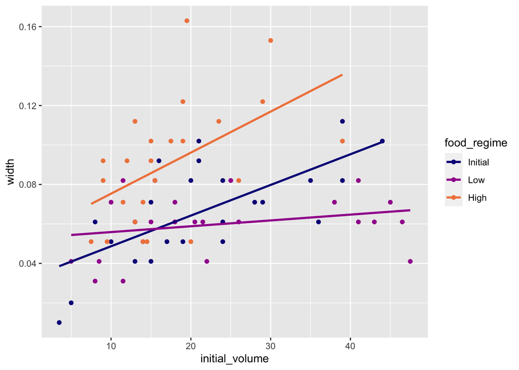

```r
ggplot(urchins,
       aes(x = initial_volume,
           y = width,
           group = food_regime,
           col = food_regime)) +
  geom_point() +
  geom_smooth(method = lm, se = FALSE) +
  scale_color_viridis_d(option = "plasma", end = .7)
```

build and fit a model

A standard two-way analysis of variance (ANOVA) model makes sense for this dataset because we have both a continuous predictor and a categorical predictor. Since the slopes appear to be different for at least two of the feeding regimes, let’s build a model that allows for two-way interactions. Specifying an R formula with our variables in this way:

width ~ initial_volume * food_regime

For this kind of model, ordinary least squares is a good initial approach. With tidymodels, we start by specifying the functional form of the model that we want using the parsnip package. Since there is a numeric outcome and the model should be linear with slopes and intercepts, the model type is “linear regression”. We can declare this with:

```r
linear_reg()
```

```
## Linear Regression Model Specification (regression)
##
## Computational engine: lm
```

```
#> Linear Regression Model Specification (regression)
#>
#> Computational engine: lm
```

now that the type of model has been specified, we can think about a method for fitting or training the model, the model engine. The engine value is often a mash-up of the software that can be used to fit or train the model as well as the estimation method. The default for linear_reg() is “lm” for ordinary least squares, as you can see above. We could set a non-default option instead:

```r
linear_reg() %>%
  set_engine("keras")
```

```
## Linear Regression Model Specification (regression)
##
## Computational engine: keras
```

```
#> Linear Regression Model Specification (regression)
#>
#> Computational engine: keras
```

The documentation page for linear_reg() lists all the possible engines. We’ll save our model object using the default engine as lm_mod.

```r
lm_mod <- linear_reg()
```

From here, the model can be estimated or trained using the fit() function:

```r
lm_fit <-
  lm_mod %>%
  fit(width ~ initial_volume * food_regime, data = urchins)
lm_fit
```

```
## parsnip model object
##
##
## Call:
## stats::lm(formula = width ~ initial_volume * food_regime, data = data)
##
## Coefficients:
##                    (Intercept)                  initial_volume
##                      0.0331216                       0.0015546
##                 food_regimeLow                 food_regimeHigh
##                      0.0197824                       0.0214111
##  initial_volume:food_regimeLow  initial_volume:food_regimeHigh
##                     -0.0012594                       0.0005254
```

```
#> parsnip model object
#>
#>
#> Call:
#> stats::lm(formula = width ~ initial_volume * food_regime, data = data)
#>
#> Coefficients:
#>                    (Intercept)                  initial_volume
#>                      0.0331216                       0.0015546
#>                 food_regimeLow                 food_regimeHigh
#>                      0.0197824                       0.0214111
#>  initial_volume:food_regimeLow  initial_volume:food_regimeHigh
#>                     -0.0012594                       0.0005254
```

```r
tidy(lm_fit)
```

```
## # A tibble: 6 × 5
##   term                            estimate std.error statistic  p.value
##   <chr>                              <dbl>     <dbl>     <dbl>    <dbl>
## 1 (Intercept)                     0.0331    0.00962      3.44  0.00100
## 2 initial_volume                  0.00155   0.000398     3.91  0.000222
## 3 food_regimeLow                  0.0198    0.0130       1.52  0.133
## 4 food_regimeHigh                 0.0214    0.0145       1.47  0.145
## 5 initial_volume:food_regimeLow  -0.00126   0.000510    -2.47  0.0162
## 6 initial_volume:food_regimeHigh  0.000525  0.000702     0.748 0.457
```

```
#> # A tibble: 6 × 5
#>   term                            estimate std.error statistic  p.value
#>   <chr>                              <dbl>     <dbl>     <dbl>    <dbl>
#> 1 (Intercept)                     0.0331    0.00962      3.44  0.00100
#> 2 initial_volume                  0.00155   0.000398     3.91  0.000222
#> 3 food_regimeLow                  0.0198    0.0130       1.52  0.133
#> 4 food_regimeHigh                 0.0214    0.0145       1.47  0.145
#> 5 initial_volume:food_regimeLow  -0.00126   0.000510    -2.47  0.0162
#> 6 initial_volume:food_regimeHigh  0.000525  0.000702     0.748 0.457
```

```r
#tidy(lm_fit) %>%
 #dwplot(dot_args = list(size = 2, color = "black"),
   #      whisker_args = list(color = "black"),
    #     vline = geom_vline(xintercept = 0, colour = "grey50", linetype = 2))
```

dot-and whisker plot of the regression results using the dotwhisker package was unable to be created due to a missing package. however, this can be createde via ggplot2 in the future

use a model to predict creating new starting point and predicting the the new outcome varables

```r
new_points <- expand.grid(initial_volume = 20,
                          food_regime = c("Initial", "Low", "High"))
new_points
```

```
##   initial_volume food_regime
## 1             20     Initial
## 2             20         Low
## 3             20        High
```

```
#>   initial_volume food_regime
#> 1             20     Initial
#> 2             20         Low
#> 3             20        High
```

```r
mean_pred <- predict(lm_fit, new_data = new_points)
mean_pred
```

```
## # A tibble: 3 × 1
##    .pred
##    <dbl>
## 1 0.0642
## 2 0.0588
## 3 0.0961
```

```
#> # A tibble: 3 × 1
#>    .pred
#>    <dbl>
#> 1 0.0642
#> 2 0.0588
#> 3 0.0961
```

```r
conf_int_pred <- predict(lm_fit,
                         new_data = new_points,
                         type = "conf_int")
conf_int_pred
```

```
## # A tibble: 3 × 2
##   .pred_lower .pred_upper
##         <dbl>       <dbl>
## 1      0.0555      0.0729
## 2      0.0499      0.0678
## 3      0.0870      0.105
```

```
#> # A tibble: 3 × 2
#>   .pred_lower .pred_upper
#>         <dbl>       <dbl>
#> 1      0.0555      0.0729
#> 2      0.0499      0.0678
#> 3      0.0870      0.105
```

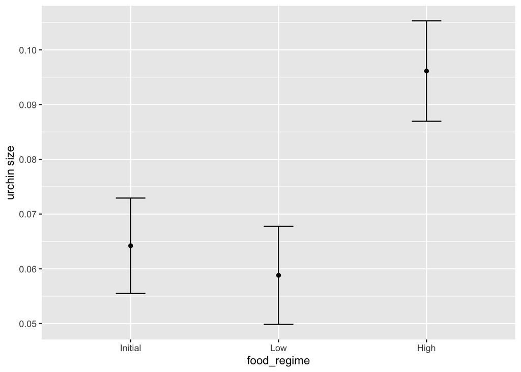

```r
# Now combine:
plot_data <-
  new_points %>%
  bind_cols(mean_pred) %>%
  bind_cols(conf_int_pred)

# and plot:
ggplot(plot_data, aes(x = food_regime)) +
  geom_point(aes(y = .pred)) +
  geom_errorbar(aes(ymin = .pred_lower,
                    ymax = .pred_upper),
                width = .2) +
  labs(y = "urchin size")
```

model with a different engine

n such an analysis, a prior distribution needs to be declared for each model parameter that represents the possible values of the parameters (before being exposed to the observed data). After some discussion, the group agrees that the priors should be bell-shaped but, since no one has any idea what the range of values should be, to take a conservative approach and make the priors wide using a Cauchy distribution (which is the same as a t-distribution with a single degree of freedom).

The documentation on the rstanarm package shows us that the stan_glm() function can be used to estimate this model, and that the function arguments that need to be specified are called prior and prior_intercept. It turns out that linear_reg() has a stan engine. Since these prior distribution arguments are specific to the Stan software, they are passed as arguments to parsnip::set_engine(). After that, the same exact fit() call is used:

```r
# set the prior distribution
prior_dist <- rstanarm::student_t(df = 1)

set.seed(123)

# make the parsnip model
bayes_mod <-
  linear_reg() %>%
  set_engine("stan",
             prior_intercept = prior_dist,
             prior = prior_dist)

# train the model
bayes_fit <-
  bayes_mod %>%
  fit(width ~ initial_volume * food_regime, data = urchins)

print(bayes_fit, digits = 5)
```

```
## parsnip model object
##
## stan_glm
##  family:       gaussian [identity]
##  formula:      width ~ initial_volume * food_regime
##  observations: 72
##  predictors:   6
## ------
##                                Median   MAD_SD
## (Intercept)                     0.03338  0.00947
## initial_volume                  0.00155  0.00039
## food_regimeLow                  0.01936  0.01348
## food_regimeHigh                 0.02073  0.01395
## initial_volume:food_regimeLow  -0.00125  0.00052
## initial_volume:food_regimeHigh  0.00055  0.00069
##
## Auxiliary parameter(s):
##       Median  MAD_SD
## sigma 0.02143 0.00180
##
## ------
## * For help interpreting the printed output see ?print.stanreg
## * For info on the priors used see ?prior_summary.stanreg
```

[output not shown]

the package rstanarm is not the docker but adding the code the script for documentation and review

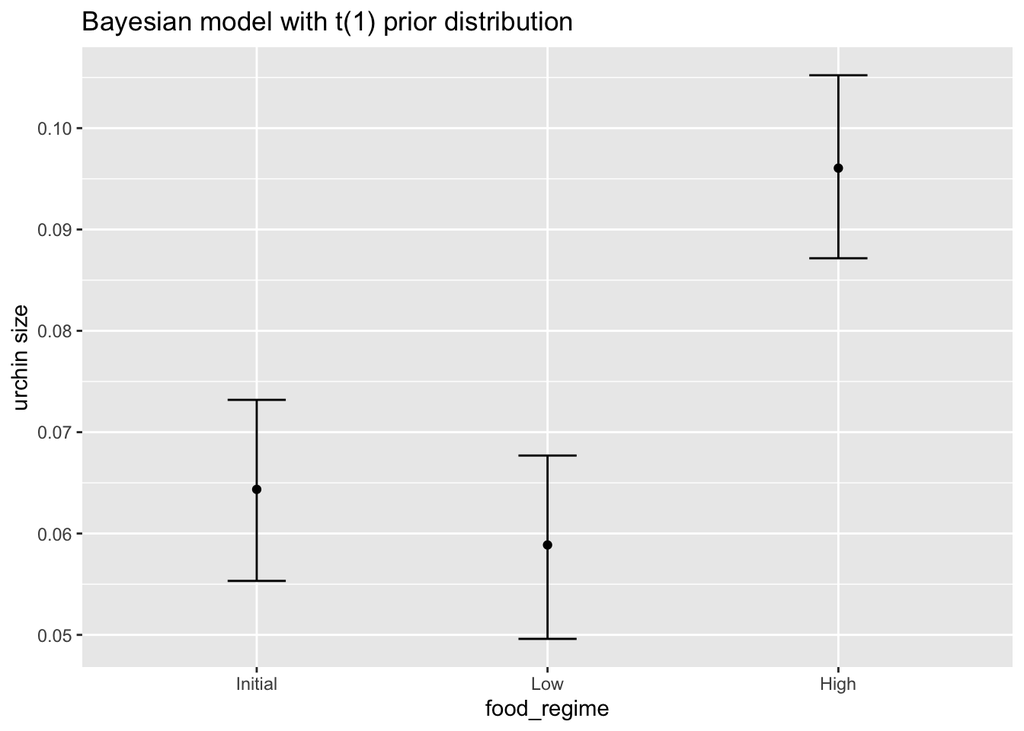

```r
bayes_plot_data <-
  new_points %>%
  bind_cols(predict(bayes_fit, new_data = new_points)) %>%
  bind_cols(predict(bayes_fit, new_data = new_points, type = "conf_int"))

ggplot(bayes_plot_data, aes(x = food_regime)) +
  geom_point(aes(y = .pred)) +
  geom_errorbar(aes(ymin = .pred_lower, ymax = .pred_upper), width = .2) +
  labs(y = "urchin size") +
  ggtitle("Bayesian model with t(1) prior distribution")
```

The extra step of defining the model using a function like linear_reg() might seem superfluous since a call to lm() is much more succinct. However, the problem with standard modeling functions is that they don’t separate what you want to do from the execution. For example, the process of executing a formula has to happen repeatedly across model calls even when the formula does not change; we can’t recycle those computations.

Also, using the tidymodels framework, we can do some interesting things by incrementally creating a model (instead of using single function call). Model tuning with tidymodels uses the specification of the model to declare what parts of the model should be tuned. That would be very difficult to do if linear_reg() immediately fit the model.

If you are familiar with the tidyverse, you may have noticed that our modeling code uses the magrittr pipe (%>%). With dplyr and other tidyverse packages, the pipe works well because all of the functions take the data as the first argument. For example:

```r
urchins %>%
  group_by(food_regime) %>%
  summarize(med_vol = median(initial_volume))
```

```
## # A tibble: 3 × 2
##   food_regime med_vol
##   <fct>         <dbl>
## 1 Initial        20.5
## 2 Low            19.2
## 3 High           15
```

```
#> # A tibble: 3 × 2
#>   food_regime med_vol
#>   <fct>         <dbl>
#> 1 Initial        20.5
#> 2 Low            19.2
#> 3 High           15
```

```r
bayes_mod %>%
  fit(width ~ initial_volume * food_regime, data = urchins)
```

```
## parsnip model object
##
## stan_glm
##  family:       gaussian [identity]
##  formula:      width ~ initial_volume * food_regime
##  observations: 72
##  predictors:   6
## ------
##                                Median MAD_SD
## (Intercept)                    0.0    0.0
## initial_volume                 0.0    0.0
## food_regimeLow                 0.0    0.0
## food_regimeHigh                0.0    0.0
## initial_volume:food_regimeLow  0.0    0.0
## initial_volume:food_regimeHigh 0.0    0.0
##
## Auxiliary parameter(s):
##       Median MAD_SD
## sigma 0.0    0.0
##
## ------
## * For help interpreting the printed output see ?print.stanreg
## * For info on the priors used see ?prior_summary.stanreg
```

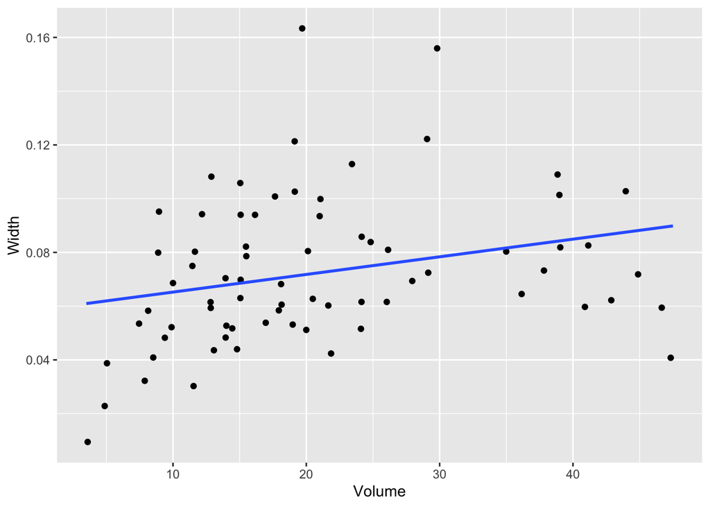

```r
ggplot(urchins,
       aes(initial_volume, width)) +      # returns a ggplot object
  geom_jitter() +                         # same
  geom_smooth(method = lm, se = FALSE) +  # same
  labs(x = "Volume", y = "Width")         # etc
```

## Preprocess your data with recipes

In our Build a Model article, we learned how to specify and train models with different engines using the parsnip package. In this article, we’ll explore another tidymodels package, recipes, which is designed to help you preprocess your data before training your model. Recipes are built as a series of preprocessing steps, such as:

converting qualitative predictors to indicator variables (also known as dummy variables), transforming data to be on a different scale (e.g., taking the logarithm of a variable), transforming whole groups of predictors together, extracting key features from raw variables (e.g., getting the day of the week out of a date variable),

and so on. If you are familiar with R’s formula interface, a lot of this might sound familiar and like what a formula already does. Recipes can be used to do many of the same things, but they have a much wider range of possibilities. This article shows how to use recipes for modeling.

```r
library(tidymodels)      # for the recipes package, along with the rest of tidymodels

# Helper packages
library(nycflights13)    # for flight data
library(skimr)           # for variable summaries
```

download data and ajdjust the data

```r
set.seed(123)

flight_data <-
  flights %>%
  mutate(
    # Convert the arrival delay to a factor
    arr_delay = ifelse(arr_delay >= 30, "late", "on_time"),
    arr_delay = factor(arr_delay),
    # We will use the date (not date-time) in the recipe below
    date = lubridate::as_date(time_hour)
  ) %>%
  # Include the weather data
  inner_join(weather, by = c("origin", "time_hour")) %>%
  # Only retain the specific columns we will use
  select(dep_time, flight, origin, dest, air_time, distance,
         carrier, date, arr_delay, time_hour) %>%
  # Exclude missing data
  na.omit() %>%
  # For creating models, it is better to have qualitative columns
  # encoded as factors (instead of character strings)
  mutate_if(is.character, as.factor)
```

```r
flight_data %>%
  count(arr_delay) %>%
  mutate(prop = n/sum(n))
```

```
## # A tibble: 2 × 3
##   arr_delay      n  prop
##   <fct>      <int> <dbl>
## 1 late       52540 0.161
## 2 on_time   273279 0.839
```

```
#> # A tibble: 2 × 3
#>   arr_delay      n  prop
#>   <fct>      <int> <dbl>
#> 1 late       52540 0.161
#> 2 on_time   273279 0.839
```

```r
glimpse(flight_data)
```

```
## Rows: 325,819
## Columns: 10
## $ dep_time  <int> 517, 533, 542, 544, 554, 554, 555, 557, 557, 558, 558, 558, …
## $ flight    <int> 1545, 1714, 1141, 725, 461, 1696, 507, 5708, 79, 301, 49, 71…
## $ origin    <fct> EWR, LGA, JFK, JFK, LGA, EWR, EWR, LGA, JFK, LGA, JFK, JFK, …
## $ dest      <fct> IAH, IAH, MIA, BQN, ATL, ORD, FLL, IAD, MCO, ORD, PBI, TPA, …
## $ air_time  <dbl> 227, 227, 160, 183, 116, 150, 158, 53, 140, 138, 149, 158, 3…
## $ distance  <dbl> 1400, 1416, 1089, 1576, 762, 719, 1065, 229, 944, 733, 1028,…
## $ carrier   <fct> UA, UA, AA, B6, DL, UA, B6, EV, B6, AA, B6, B6, UA, UA, AA, …
## $ date      <date> 2013-01-01, 2013-01-01, 2013-01-01, 2013-01-01, 2013-01-01,…
## $ arr_delay <fct> on_time, on_time, late, on_time, on_time, on_time, on_time, …
## $ time_hour <dttm> 2013-01-01 05:00:00, 2013-01-01 05:00:00, 2013-01-01 05:00:…
```

```
#> Rows: 325,819
#> Columns: 10
#> $ dep_time  <int> 517, 533, 542, 544, 554, 554, 555, 557, 557, 558, 558, 558, …
#> $ flight    <int> 1545, 1714, 1141, 725, 461, 1696, 507, 5708, 79, 301, 49, 71…
#> $ origin    <fct> EWR, LGA, JFK, JFK, LGA, EWR, EWR, LGA, JFK, LGA, JFK, JFK, …
#> $ dest      <fct> IAH, IAH, MIA, BQN, ATL, ORD, FLL, IAD, MCO, ORD, PBI, TPA, …
#> $ air_time  <dbl> 227, 227, 160, 183, 116, 150, 158, 53, 140, 138, 149, 158, 3…
#> $ distance  <dbl> 1400, 1416, 1089, 1576, 762, 719, 1065, 229, 944, 733, 1028,…
#> $ carrier   <fct> UA, UA, AA, B6, DL, UA, B6, EV, B6, AA, B6, B6, UA, UA, AA, …
#> $ date      <date> 2013-01-01, 2013-01-01, 2013-01-01, 2013-01-01, 2013-01-01,…
#> $ arr_delay <fct> on_time, on_time, late, on_time, on_time, on_time, on_time, …
#> $ time_hour <dttm> 2013-01-01 05:00:00, 2013-01-01 05:00:00, 2013-01-01 05:00:…
```

```r
flight_data %>%
  skimr::skim(dest, carrier)
```

Data summary

| Name | Piped data |
| --- | --- |
| Number of rows | 325819 |
| Number of columns | 10 |
| _______________________ |  |
| Column type frequency: |  |
| factor | 2 |
| ________________________ |  |
| Group variables | None |

**Variable type: factor**

| skim_variable | n_missing | complete_rate | ordered | n_unique | top_counts |
| --- | --- | --- | --- | --- | --- |
| dest | 0 | 1 | FALSE | 104 | ATL: 16771, ORD: 16507, LAX: 15942, BOS: 14948 |
| carrier | 0 | 1 | FALSE | 16 | UA: 57489, B6: 53715, EV: 50868, DL: 47465 |

Because we’ll be using a simple logistic regression model, the variables dest and carrier will be converted to dummy variables. However, some of these values do not occur very frequently and this could complicate our analysis. We’ll discuss specific steps later in this article that we can add to our recipe to address this issue before modeling

data splitting

```r
# Fix the random numbers by setting the seed
# This enables the analysis to be reproducible when random numbers are used
set.seed(222)
# Put 3/4 of the data into the training set
data_split <- initial_split(flight_data, prop = 3/4)

# Create data frames for the two sets:
train_data <- training(data_split)
test_data  <- testing(data_split)
```

```r
flights_rec <-
  recipe(arr_delay ~ ., data = train_data)
```

The recipe() function as we used it here has two arguments:

A formula. Any variable on the left-hand side of the tilde (~) is considered the model outcome (here, arr_delay). On the right-hand side of the tilde are the predictors. Variables may be listed by name, or you can use the dot (.) to indicate all other variables as predictors. The data. A recipe is associated with the data set used to create the model. This will typically be the training set, so data = train_data here. Naming a data set doesn’t actually change the data itself; it is only used to catalog the names of the variables and their types, like factors, integers, dates, etc.

Now we can add roles to this recipe. We can use the update_role() function to let recipes know that flight and time_hour are variables with a custom role that we called “ID” (a role can have any character value). Whereas our formula included all variables in the training set other than arr_delay as predictors, this tells the recipe to keep these two variables but not use them as either outcomes or predictors.

```r
flights_rec <-
  recipe(arr_delay ~ ., data = train_data) %>%
  update_role(flight, time_hour, new_role = "ID")
```

This step of adding roles to a recipe is optional; the purpose of using it here is that those two variables can be retained in the data but not included in the model. This can be convenient when, after the model is fit, we want to investigate some poorly predicted value. These ID columns will be available and can be used to try to understand what went wrong.

```r
summary(flights_rec)
```

```
## # A tibble: 10 × 4
##    variable  type    role      source
##    <chr>     <chr>   <chr>     <chr>
##  1 dep_time  numeric predictor original
##  2 flight    numeric ID        original
##  3 origin    nominal predictor original
##  4 dest      nominal predictor original
##  5 air_time  numeric predictor original
##  6 distance  numeric predictor original
##  7 carrier   nominal predictor original
##  8 date      date    predictor original
##  9 time_hour date    ID        original
## 10 arr_delay nominal outcome   original
```

```
#> # A tibble: 10 × 4
#>    variable  type    role      source
#>    <chr>     <chr>   <chr>     <chr>
#>  1 dep_time  numeric predictor original
#>  2 flight    numeric ID        original
#>  3 origin    nominal predictor original
#>  4 dest      nominal predictor original
#>  5 air_time  numeric predictor original
#>  6 distance  numeric predictor original
#>  7 carrier   nominal predictor original
#>  8 date      date    predictor original
#>  9 time_hour date    ID        original
#> 10 arr_delay nominal outcome   original
```

create features Now we can start adding steps onto our recipe using the pipe operator. Perhaps it is reasonable for the date of the flight to have an effect on the likelihood of a late arrival. A little bit of feature engineering might go a long way to improving our model. How should the date be encoded into the model? The date column has an R date object so including that column “as is” will mean that the model will convert it to a numeric format equal to the number of days after a reference date:

```r
flight_data %>%
  distinct(date) %>%
  mutate(numeric_date = as.numeric(date))
```

```
## # A tibble: 364 × 2
##    date       numeric_date
##    <date>            <dbl>
##  1 2013-01-01        15706
##  2 2013-01-02        15707
##  3 2013-01-03        15708
##  4 2013-01-04        15709
##  5 2013-01-05        15710
##  6 2013-01-06        15711
##  7 2013-01-07        15712
##  8 2013-01-08        15713
##  9 2013-01-09        15714
## 10 2013-01-10        15715
## # … with 354 more rows
## # ℹ Use `print(n = ...)` to see more rows
```

```
#> # A tibble: 364 × 2
#>   date       numeric_date
#>   <date>            <dbl>
#> 1 2013-01-01        15706
#> 2 2013-01-02        15707
#> 3 2013-01-03        15708
#> 4 2013-01-04        15709
#> 5 2013-01-05        15710
#> # … with 359 more rows
```

```r
flights_rec <-
  recipe(arr_delay ~ ., data = train_data) %>%
  update_role(flight, time_hour, new_role = "ID") %>%
  step_date(date, features = c("dow", "month")) %>%
  step_holiday(date,
               holidays = timeDate::listHolidays("US"),
               keep_original_cols = FALSE)
```

creating dummy varibales

```r
flights_rec <-
  recipe(arr_delay ~ ., data = train_data) %>%
  update_role(flight, time_hour, new_role = "ID") %>%
  step_date(date, features = c("dow", "month")) %>%
  step_holiday(date,
               holidays = timeDate::listHolidays("US"),
               keep_original_cols = FALSE) %>%
  step_dummy(all_nominal_predictors())
```

```r
test_data %>%
  distinct(dest) %>%
  anti_join(train_data)
```

```
## # A tibble: 1 × 1
##   dest
##   <fct>
## 1 LEX
```

```
#> # A tibble: 1 × 1
#>   dest
#>   <fct>
#> 1 LEX
```

```r
flights_rec <-
  recipe(arr_delay ~ ., data = train_data) %>%
  update_role(flight, time_hour, new_role = "ID") %>%
  step_date(date, features = c("dow", "month")) %>%
  step_holiday(date,
               holidays = timeDate::listHolidays("US"),
               keep_original_cols = FALSE) %>%
  step_dummy(all_nominal_predictors()) %>%
  step_zv(all_predictors())
```

fir a model with a recipe Let’s use logistic regression to model the flight data. As we saw in Build a Model, we start by building a model specification using the parsnip package:

```r
lr_mod <-
  logistic_reg() %>%
  set_engine("glm")
```

We will want to use our recipe across several steps as we train and test our model. We will:

Process the recipe using the training set: This involves any estimation or calculations based on the training set. For our recipe, the training set will be used to determine which predictors should be converted to dummy variables and which predictors will have zero-variance in the training set, and should be slated for removal.

Apply the recipe to the training set: We create the final predictor set on the training set.

Apply the recipe to the test set: We create the final predictor set on the test set. Nothing is recomputed and no information from the test set is used here; the dummy variable and zero-variance results from the training set are applied to the test set.

To simplify this process, we can use a model workflow, which pairs a model and recipe together. This is a straightforward approach because different recipes are often needed for different models, so when a model and recipe are bundled, it becomes easier to train and test workflows. We’ll use the workflows package from tidymodels to bundle our parsnip model (lr_mod) with our recipe (flights_rec).

```r
flights_wflow <-
  workflow() %>%
  add_model(lr_mod) %>%
  add_recipe(flights_rec)

flights_wflow
```

```
## ══ Workflow ════════════════════════════════════════════════════════════════════
## Preprocessor: Recipe
## Model: logistic_reg()
##
## ── Preprocessor ────────────────────────────────────────────────────────────────
## 4 Recipe Steps
##
## • step_date()
## • step_holiday()
## • step_dummy()
## • step_zv()
##
## ── Model ───────────────────────────────────────────────────────────────────────
## Logistic Regression Model Specification (classification)
##
## Computational engine: glm
```

```
#> ══ Workflow ══════════════════════════════════════════════════════════
#> Preprocessor: Recipe
#> Model: logistic_reg()
#>
#> ── Preprocessor ──────────────────────────────────────────────────────
#> 4 Recipe Steps
#>
#> • step_date()
#> • step_holiday()
#> • step_dummy()
#> • step_zv()
#>
#> ── Model ─────────────────────────────────────────────────────────────
#> Logistic Regression Model Specification (classification)
#>
#> Computational engine: glm
```

```r
flights_fit <-
  flights_wflow %>%
  fit(data = train_data)
```

This object has the finalized recipe and fitted model objects inside. You may want to extract the model or recipe objects from the workflow. To do this, you can use the helper functions extract_fit_parsnip() and extract_recipe(). For example, here we pull the fitted model object then use the broom::tidy() function to get a tidy tibble of model coefficients:

```r
flights_fit %>%
  extract_fit_parsnip() %>%
  tidy()
```

```
## # A tibble: 157 × 5
##    term                         estimate std.error statistic  p.value
##    <chr>                           <dbl>     <dbl>     <dbl>    <dbl>
##  1 (Intercept)                   7.28    2.73           2.67 7.64e- 3
##  2 dep_time                     -0.00166 0.0000141   -118.   0
##  3 air_time                     -0.0440  0.000563     -78.2  0
##  4 distance                      0.00507 0.00150        3.38 7.32e- 4
##  5 date_USChristmasDay           1.33    0.177          7.49 6.93e-14
##  6 date_USColumbusDay            0.724   0.170          4.25 2.13e- 5
##  7 date_USCPulaskisBirthday      0.807   0.139          5.80 6.57e- 9
##  8 date_USDecorationMemorialDay  0.585   0.117          4.98 6.32e- 7
##  9 date_USElectionDay            0.948   0.190          4.98 6.25e- 7
## 10 date_USGoodFriday             1.25    0.167          7.45 9.40e-14
## # … with 147 more rows
## # ℹ Use `print(n = ...)` to see more rows
```

```
#> # A tibble: 157 × 5
#>   term                estimate std.error statistic  p.value
#>   <chr>                  <dbl>     <dbl>     <dbl>    <dbl>
#> 1 (Intercept)          7.28    2.73           2.67 7.64e- 3
#> 2 dep_time            -0.00166 0.0000141   -118.   0
#> 3 air_time            -0.0440  0.000563     -78.2  0
#> 4 distance             0.00507 0.00150        3.38 7.32e- 4
#> 5 date_USChristmasDay  1.33    0.177          7.49 6.93e-14
#> # … with 152 more rows
```

use a trained workflow to predict

Our goal was to predict whether a plane arrives more than 30 minutes late. We have just:

Built the model (lr_mod),

Created a preprocessing recipe (flights_rec),

Bundled the model and recipe (flights_wflow), and

Trained our workflow using a single call to fit().

The next step is to use the trained workflow (flights_fit) to predict with the unseen test data, which we will do with a single call to predict(). The predict() method applies the recipe to the new data, then passes them to the fitted model.

```r
predict(flights_fit, test_data)
```

```
## # A tibble: 81,455 × 1
##    .pred_class
##    <fct>
##  1 on_time
##  2 on_time
##  3 on_time
##  4 on_time
##  5 on_time
##  6 on_time
##  7 on_time
##  8 on_time
##  9 on_time
## 10 on_time
## # … with 81,445 more rows
## # ℹ Use `print(n = ...)` to see more rows
```

```
#> # A tibble: 81,455 × 1
#>   .pred_class
#>   <fct>
#> 1 on_time
#> 2 on_time
#> 3 on_time
#> 4 on_time
#> 5 on_time
#> # … with 81,450 more rows
```

Because our outcome variable here is a factor, the output from predict() returns the predicted class: late versus on_time. But, let’s say we want the predicted class probabilities for each flight instead. To return those, we can specify type = “prob” when we use predict() or use augment() with the model plus test data to save them together:

```r
flights_aug <-
  augment(flights_fit, test_data)

# The data look like:
flights_aug %>%
  select(arr_delay, time_hour, flight, .pred_class, .pred_on_time)
```

```
## # A tibble: 81,455 × 5
##    arr_delay time_hour           flight .pred_class .pred_on_time
##    <fct>     <dttm>               <int> <fct>               <dbl>
##  1 on_time   2013-01-01 05:00:00   1545 on_time             0.945
##  2 on_time   2013-01-01 05:00:00   1714 on_time             0.949
##  3 on_time   2013-01-01 06:00:00    507 on_time             0.964
##  4 on_time   2013-01-01 06:00:00   5708 on_time             0.961
##  5 on_time   2013-01-01 06:00:00     71 on_time             0.962
##  6 on_time   2013-01-01 06:00:00    194 on_time             0.975
##  7 on_time   2013-01-01 06:00:00   1124 on_time             0.963
##  8 on_time   2013-01-01 05:00:00   1806 on_time             0.981
##  9 on_time   2013-01-01 06:00:00   1187 on_time             0.935
## 10 on_time   2013-01-01 06:00:00   4650 on_time             0.931
## # … with 81,445 more rows
## # ℹ Use `print(n = ...)` to see more rows
```

```
#> # A tibble: 81,455 × 5
#>   arr_delay time_hour           flight .pred_class .pred_on_time
#>   <fct>     <dttm>               <int> <fct>               <dbl>
#> 1 on_time   2013-01-01 05:00:00   1545 on_time             0.945
#> 2 on_time   2013-01-01 05:00:00   1714 on_time             0.949
#> 3 on_time   2013-01-01 06:00:00    507 on_time             0.964
#> 4 on_time   2013-01-01 06:00:00   5708 on_time             0.961
#> 5 on_time   2013-01-01 06:00:00     71 on_time             0.962
#> # … with 81,450 more rows
```

Now that we have a tibble with our predicted class probabilities, how will we evaluate the performance of our workflow? We can see from these first few rows that our model predicted these 5 on time flights correctly because the values of .pred_on_time are p > .50. But we also know that we have 81,455 rows total to predict. We would like to calculate a metric that tells how well our model predicted late arrivals, compared to the true status of our outcome variable, arr_delay.

Let’s use the area under the ROC curve as our metric, computed using roc_curve() and roc_auc() from the yardstick package.

To generate a ROC curve, we need the predicted class probabilities for late and on_time, which we just calculated in the code chunk above. We can create the ROC curve with these values, using roc_curve() and then piping to the autoplot() method:

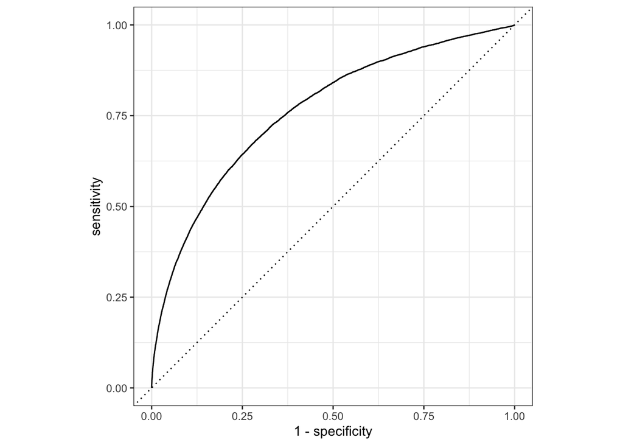

```r
flights_aug %>%
  roc_curve(truth = arr_delay, .pred_late) %>%
  autoplot()
```

```r
flights_aug %>%
  roc_auc(truth = arr_delay, .pred_late)
```

```
## # A tibble: 1 × 3
##   .metric .estimator .estimate
##   <chr>   <chr>          <dbl>
## 1 roc_auc binary         0.764
```

```
#> # A tibble: 1 × 3
#>   .metric .estimator .estimate
#>   <chr>   <chr>          <dbl>
#> 1 roc_auc binary         0.764
```

## evaluate your model with resampling

So far, we have built a model and preprocessed data with a recipe. We also introduced workflows as a way to bundle a parsnip model and recipe together. Once we have a model trained, we need a way to measure how well that model predicts new data. This tutorial explains how to characterize model performance based on resampling statistics.

```r
library(tidymodels) # for the rsample package, along with the rest of tidymodels

# Helper packages
library(modeldata)  # for the cells data
```

```r
data(cells, package = "modeldata")
cells
```

```
## # A tibble: 2,019 × 58
##    case  class angle_c…¹ area_…² avg_i…³ avg_i…⁴ avg_i…⁵ avg_i…⁶ conve…⁷ conve…⁸
##    <fct> <fct>     <dbl>   <int>   <dbl>   <dbl>   <dbl>   <dbl>   <dbl>   <dbl>
##  1 Test  PS       143.       185    15.7    4.95    9.55    2.21    1.12   0.920
##  2 Train PS       134.       819    31.9  207.     69.9   164.      1.26   0.797
##  3 Train WS       107.       431    28.0  116.     63.9   107.      1.05   0.935
##  4 Train PS        69.2      298    19.5  102.     28.2    31.0     1.20   0.866
##  5 Test  PS         2.89     285    24.3  112.     20.5    40.6     1.11   0.957
##  6 Test  WS        40.7      172   326.   654.    129.    347.      1.01   0.993
##  7 Test  WS       174.       177   260.   596.    124.    273.      1.01   0.984
##  8 Test  PS       180.       251    18.3    5.73   17.2     1.55    1.20   0.831
##  9 Test  WS        18.9      495    16.1   89.5    13.7    51.4     1.19   0.822
## 10 Test  WS       153.       384    17.7   89.9    20.4    63.1     1.16   0.865
## # … with 2,009 more rows, 48 more variables: diff_inten_density_ch_1 <dbl>,
## #   diff_inten_density_ch_3 <dbl>, diff_inten_density_ch_4 <dbl>,
## #   entropy_inten_ch_1 <dbl>, entropy_inten_ch_3 <dbl>,
## #   entropy_inten_ch_4 <dbl>, eq_circ_diam_ch_1 <dbl>,
## #   eq_ellipse_lwr_ch_1 <dbl>, eq_ellipse_oblate_vol_ch_1 <dbl>,
## #   eq_ellipse_prolate_vol_ch_1 <dbl>, eq_sphere_area_ch_1 <dbl>,
## #   eq_sphere_vol_ch_1 <dbl>, fiber_align_2_ch_3 <dbl>, …
## # ℹ Use `print(n = ...)` to see more rows, and `colnames()` to see all variable names
```

```
#> # A tibble: 2,019 × 58
#>   case  class angle_ch_1 area_ch_1 avg_inten_ch_1 avg_inten_ch_2 avg_inten_ch_3
#>   <fct> <fct>      <dbl>     <int>          <dbl>          <dbl>          <dbl>
#> 1 Test  PS        143.         185           15.7           4.95           9.55
#> 2 Train PS        134.         819           31.9         207.            69.9
#> 3 Train WS        107.         431           28.0         116.            63.9
#> 4 Train PS         69.2        298           19.5         102.            28.2
#> 5 Test  PS          2.89       285           24.3         112.            20.5
#> # … with 2,014 more rows, and 51 more variables: avg_inten_ch_4 <dbl>,
#> #   convex_hull_area_ratio_ch_1 <dbl>, convex_hull_perim_ratio_ch_1 <dbl>,
#> #   diff_inten_density_ch_1 <dbl>, diff_inten_density_ch_3 <dbl>, …
```

```r
cells
```

```
## # A tibble: 2,019 × 58
##    case  class angle_c…¹ area_…² avg_i…³ avg_i…⁴ avg_i…⁵ avg_i…⁶ conve…⁷ conve…⁸
##    <fct> <fct>     <dbl>   <int>   <dbl>   <dbl>   <dbl>   <dbl>   <dbl>   <dbl>
##  1 Test  PS       143.       185    15.7    4.95    9.55    2.21    1.12   0.920
##  2 Train PS       134.       819    31.9  207.     69.9   164.      1.26   0.797
##  3 Train WS       107.       431    28.0  116.     63.9   107.      1.05   0.935
##  4 Train PS        69.2      298    19.5  102.     28.2    31.0     1.20   0.866
##  5 Test  PS         2.89     285    24.3  112.     20.5    40.6     1.11   0.957
##  6 Test  WS        40.7      172   326.   654.    129.    347.      1.01   0.993
##  7 Test  WS       174.       177   260.   596.    124.    273.      1.01   0.984
##  8 Test  PS       180.       251    18.3    5.73   17.2     1.55    1.20   0.831
##  9 Test  WS        18.9      495    16.1   89.5    13.7    51.4     1.19   0.822
## 10 Test  WS       153.       384    17.7   89.9    20.4    63.1     1.16   0.865
## # … with 2,009 more rows, 48 more variables: diff_inten_density_ch_1 <dbl>,
## #   diff_inten_density_ch_3 <dbl>, diff_inten_density_ch_4 <dbl>,
## #   entropy_inten_ch_1 <dbl>, entropy_inten_ch_3 <dbl>,
## #   entropy_inten_ch_4 <dbl>, eq_circ_diam_ch_1 <dbl>,
## #   eq_ellipse_lwr_ch_1 <dbl>, eq_ellipse_oblate_vol_ch_1 <dbl>,
## #   eq_ellipse_prolate_vol_ch_1 <dbl>, eq_sphere_area_ch_1 <dbl>,
## #   eq_sphere_vol_ch_1 <dbl>, fiber_align_2_ch_3 <dbl>, …
## # ℹ Use `print(n = ...)` to see more rows, and `colnames()` to see all variable names
```

```
#> # A tibble: 2,019 × 58
#>   case  class angle_ch_1 area_ch_1 avg_inten_ch_1 avg_inten_ch_2 avg_inten_ch_3
#>   <fct> <fct>      <dbl>     <int>          <dbl>          <dbl>          <dbl>
#> 1 Test  PS        143.         185           15.7           4.95           9.55
#> 2 Train PS        134.         819           31.9         207.            69.9
#> 3 Train WS        107.         431           28.0         116.            63.9
#> 4 Train PS         69.2        298           19.5         102.            28.2
#> 5 Test  PS          2.89       285           24.3         112.            20.5
#> # … with 2,014 more rows, and 51 more variables: avg_inten_ch_4 <dbl>,
#> #   convex_hull_area_ratio_ch_1 <dbl>, convex_hull_perim_ratio_ch_1 <dbl>,
#> #   diff_inten_density_ch_1 <dbl>, diff_inten_density_ch_3 <dbl>, …
```

```r
cells %>%
  count(class) %>%
  mutate(prop = n/sum(n))
```

```
## # A tibble: 2 × 3
##   class     n  prop
##   <fct> <int> <dbl>
## 1 PS     1300 0.644
## 2 WS      719 0.356
```

```
#> # A tibble: 2 × 3
#>   class     n  prop
#>   <fct> <int> <dbl>
#> 1 PS     1300 0.644
#> 2 WS      719 0.356
```

data splitting There are different ways to create these partitions of the data. The most common approach is to use a random sample. Suppose that one quarter of the data were reserved for the test set. Random sampling would randomly select 25% for the test set and use the remainder for the training set. We can use the rsample package for this purpose.

Since random sampling uses random numbers, it is important to set the random number seed. This ensures that the random numbers can be reproduced at a later time (if needed).

The function rsample::initial_split() takes the original data and saves the information on how to make the partitions. In the original analysis, the authors made their own training/test set and that information is contained in the column case. To demonstrate how to make a split, we’ll remove this column before we make our own split:

```r
set.seed(123)
cell_split <- initial_split(cells %>% select(-case),
                            strata = class)
```

Here we used the strata argument, which conducts a stratified split. This ensures that, despite the imbalance we noticed in our class variable, our training and test data sets will keep roughly the same proportions of poorly and well-segmented cells as in the original data. After the initial_split, the training() and testing() functions return the actual data sets.

```r
cell_train <- training(cell_split)
cell_test  <- testing(cell_split)

nrow(cell_train)
```

```
## [1] 1514
```

```
#> [1] 1514
```

```r
nrow(cell_train)/nrow(cells)
```

```
## [1] 0.7498762
```

```
#> [1] 0.7498762
```

```r
# training set proportions by class
cell_train %>%
  count(class) %>%
  mutate(prop = n/sum(n))
```

```
## # A tibble: 2 × 3
##   class     n  prop
##   <fct> <int> <dbl>
## 1 PS      975 0.644
## 2 WS      539 0.356
```

```
#> # A tibble: 2 × 3
#>   class     n  prop
#>   <fct> <int> <dbl>
#> 1 PS      975 0.644
#> 2 WS      539 0.356
```

```r
# test set proportions by class
cell_test %>%
  count(class) %>%
  mutate(prop = n/sum(n))
```

```
## # A tibble: 2 × 3
##   class     n  prop
##   <fct> <int> <dbl>
## 1 PS      325 0.644
## 2 WS      180 0.356
```

```
#> # A tibble: 2 × 3
#>   class     n  prop
#>   <fct> <int> <dbl>
#> 1 PS      325 0.644
#> 2 WS      180 0.356
```

modeling

Random forest models are ensembles of decision trees. A large number of decision tree models are created for the ensemble based on slightly different versions of the training set. When creating the individual decision trees, the fitting process encourages them to be as diverse as possible. The collection of trees are combined into the random forest model and, when a new sample is predicted, the votes from each tree are used to calculate the final predicted value for the new sample. For categorical outcome variables like class in our cells data example, the majority vote across all the trees in the random forest determines the predicted class for the new sample.

One of the benefits of a random forest model is that it is very low maintenance; it requires very little preprocessing of the data and the default parameters tend to give reasonable results. For that reason, we won’t create a recipe for the cells data.

At the same time, the number of trees in the ensemble should be large (in the thousands) and this makes the model moderately expensive to compute.

To fit a random forest model on the training set, let’s use the parsnip package with the ranger engine. We first define the model that we want to create:

```r
rf_mod <-
  rand_forest(trees = 1000) %>%
  set_engine("ranger") %>%
  set_mode("classification")
```

Starting with this parsnip model object, the fit() function can be used with a model formula. Since random forest models use random numbers, we again set the seed prior to computing:

```r
set.seed(234)
rf_fit <-
  rf_mod %>%
  fit(class ~ ., data = cell_train)
rf_fit
```

```
## parsnip model object
##
## Ranger result
##
## Call:
##  ranger::ranger(x = maybe_data_frame(x), y = y, num.trees = ~1000,      num.threads = 1, verbose = FALSE, seed = sample.int(10^5,          1), probability = TRUE)
##
## Type:                             Probability estimation
## Number of trees:                  1000
## Sample size:                      1514
## Number of independent variables:  56
## Mtry:                             7
## Target node size:                 10
## Variable importance mode:         none
## Splitrule:                        gini
## OOB prediction error (Brier s.):  0.1189338
```

```
#> parsnip model object
#>
#> Ranger result
#>
#> Call:
#>  ranger::ranger(x = maybe_data_frame(x), y = y, num.trees = ~1000,      num.threads = 1, verbose = FALSE, seed = sample.int(10^5,          1), probability = TRUE)
#>
#> Type:                             Probability estimation
#> Number of trees:                  1000
#> Sample size:                      1514
#> Number of independent variables:  56
#> Mtry:                             7
#> Target node size:                 10
#> Variable importance mode:         none
#> Splitrule:                        gini
#> OOB prediction error (Brier s.):  0.1189338
```

estimating performance

During a modeling project, we might create a variety of different models. To choose between them, we need to consider how well these models do, as measured by some performance statistics. In our example in this article, some options we could use are:

the area under the Receiver Operating Characteristic (ROC) curve, and overall classification accuracy. The ROC curve uses the class probability estimates to give us a sense of performance across the entire set of potential probability cutoffs. Overall accuracy uses the hard class predictions to measure performance. The hard class predictions tell us whether our model predicted PS or WS for each cell. But, behind those predictions, the model is actually estimating a probability. A simple 50% probability cutoff is used to categorize a cell as poorly segmented.

The yardstick package has functions for computing both of these measures called roc_auc() and accuracy().

At first glance, it might seem like a good idea to use the training set data to compute these statistics. (This is actually a very bad idea.) Let’s see what happens if we try this. To evaluate performance based on the training set, we call the predict() method to get both types of predictions (i.e. probabilities and hard class predictions).

```r
rf_training_pred <-
  predict(rf_fit, cell_train) %>%
  bind_cols(predict(rf_fit, cell_train, type = "prob")) %>%
  # Add the true outcome data back in
  bind_cols(cell_train %>%
              select(class))
```

Using the yardstick functions, this model has spectacular results, so spectacular that you might be starting to get suspicious:

```r
rf_training_pred %>%                # training set predictions
  roc_auc(truth = class, .pred_PS)
```

```
## # A tibble: 1 × 3
##   .metric .estimator .estimate
##   <chr>   <chr>          <dbl>
## 1 roc_auc binary          1.00
```

```
#> # A tibble: 1 × 3
#>   .metric .estimator .estimate
#>   <chr>   <chr>          <dbl>
#> 1 roc_auc binary          1.00
```

```r
rf_training_pred %>%                # training set predictions
  accuracy(truth = class, .pred_class)
```

```
## # A tibble: 1 × 3
##   .metric  .estimator .estimate
##   <chr>    <chr>          <dbl>
## 1 accuracy binary         0.991
```

```
#> # A tibble: 1 × 3
#>   .metric  .estimator .estimate
#>   <chr>    <chr>          <dbl>
#> 1 accuracy binary         0.991
```

Now that we have this model with exceptional performance, we proceed to the test set. Unfortunately, we discover that, although our results aren’t bad, they are certainly worse than what we initially thought based on predicting the training set:

```r
rf_testing_pred <-
  predict(rf_fit, cell_test) %>%
  bind_cols(predict(rf_fit, cell_test, type = "prob")) %>%
  bind_cols(cell_test %>% select(class))
```

```r
rf_testing_pred %>%                   # test set predictions
  roc_auc(truth = class, .pred_PS)
```

```
## # A tibble: 1 × 3
##   .metric .estimator .estimate
##   <chr>   <chr>          <dbl>
## 1 roc_auc binary         0.891
```

```
#> # A tibble: 1 × 3
#>   .metric .estimator .estimate
#>   <chr>   <chr>          <dbl>
#> 1 roc_auc binary         0.891
```

```r
rf_testing_pred %>%                   # test set predictions
  accuracy(truth = class, .pred_class)
```

```
## # A tibble: 1 × 3
##   .metric  .estimator .estimate
##   <chr>    <chr>          <dbl>
## 1 accuracy binary         0.816
```

```
#> # A tibble: 1 × 3
#>   .metric  .estimator .estimate
#>   <chr>    <chr>          <dbl>
#> 1 accuracy binary         0.816
```

WHAT HAPPENED HERE? There are several reasons why training set statistics like the ones shown in this section can be unrealistically optimistic:

Models like random forests, neural networks, and other black-box methods can essentially memorize the training set. Re-predicting that same set should always result in nearly perfect results. The training set does not have the capacity to be a good arbiter of performance. It is not an independent piece of information; predicting the training set can only reflect what the model already knows. To understand that second point better, think about an analogy from teaching. Suppose you give a class a test, then give them the answers, then provide the same test. The student scores on the second test do not accurately reflect what they know about the subject; these scores would probably be higher than their results on the first test.

fit a model with resampling To generate these results, the first step is to create a resampling object using rsample. There are several resampling methods implemented in rsample; cross-validation folds can be created using vfold_cv():

```r
set.seed(345)
folds <- vfold_cv(cell_train, v = 10)
folds
```

```
## #  10-fold cross-validation
## # A tibble: 10 × 2
##    splits             id
##    <list>             <chr>
##  1 <split [1362/152]> Fold01
##  2 <split [1362/152]> Fold02
##  3 <split [1362/152]> Fold03
##  4 <split [1362/152]> Fold04
##  5 <split [1363/151]> Fold05
##  6 <split [1363/151]> Fold06
##  7 <split [1363/151]> Fold07
##  8 <split [1363/151]> Fold08
##  9 <split [1363/151]> Fold09
## 10 <split [1363/151]> Fold10
```

```
#> #  10-fold cross-validation
#> # A tibble: 10 × 2
#>    splits             id
#>    <list>             <chr>
#>  1 <split [1362/152]> Fold01
#>  2 <split [1362/152]> Fold02
#>  3 <split [1362/152]> Fold03
#>  4 <split [1362/152]> Fold04
#>  5 <split [1363/151]> Fold05
#>  6 <split [1363/151]> Fold06
#>  7 <split [1363/151]> Fold07
#>  8 <split [1363/151]> Fold08
#>  9 <split [1363/151]> Fold09
#> 10 <split [1363/151]> Fold10
```

The list column for splits contains the information on which rows belong in the analysis and assessment sets. There are functions that can be used to extract the individual resampled data called analysis() and assessment().

However, the tune package contains high-level functions that can do the required computations to resample a model for the purpose of measuring performance. You have several options for building an object for resampling:

Resample a model specification preprocessed with a formula or recipe, or Resample a workflow() that bundles together a model specification and formula/recipe. For this example, let’s use a workflow() that bundles together the random forest model and a formula, since we are not using a recipe. Whichever of these options you use, the syntax to fit_resamples() is very similar to fit():

```r
rf_wf <-
  workflow() %>%
  add_model(rf_mod) %>%
  add_formula(class ~ .)

set.seed(456)
rf_fit_rs <-
  rf_wf %>%
  fit_resamples(folds)
```

```r
rf_fit_rs
```

```
## # Resampling results
## # 10-fold cross-validation
## # A tibble: 10 × 4
##    splits             id     .metrics         .notes
##    <list>             <chr>  <list>           <list>
##  1 <split [1362/152]> Fold01 <tibble [2 × 4]> <tibble [0 × 3]>
##  2 <split [1362/152]> Fold02 <tibble [2 × 4]> <tibble [0 × 3]>
##  3 <split [1362/152]> Fold03 <tibble [2 × 4]> <tibble [0 × 3]>
##  4 <split [1362/152]> Fold04 <tibble [2 × 4]> <tibble [0 × 3]>
##  5 <split [1363/151]> Fold05 <tibble [2 × 4]> <tibble [0 × 3]>
##  6 <split [1363/151]> Fold06 <tibble [2 × 4]> <tibble [0 × 3]>
##  7 <split [1363/151]> Fold07 <tibble [2 × 4]> <tibble [0 × 3]>
##  8 <split [1363/151]> Fold08 <tibble [2 × 4]> <tibble [0 × 3]>
##  9 <split [1363/151]> Fold09 <tibble [2 × 4]> <tibble [0 × 3]>
## 10 <split [1363/151]> Fold10 <tibble [2 × 4]> <tibble [0 × 3]>
```

```
#> # Resampling results
#> # 10-fold cross-validation
#> # A tibble: 10 × 4
#>    splits             id     .metrics         .notes
#>    <list>             <chr>  <list>           <list>
#>  1 <split [1362/152]> Fold01 <tibble [2 × 4]> <tibble [0 × 3]>
#>  2 <split [1362/152]> Fold02 <tibble [2 × 4]> <tibble [0 × 3]>
#>  3 <split [1362/152]> Fold03 <tibble [2 × 4]> <tibble [0 × 3]>
#>  4 <split [1362/152]> Fold04 <tibble [2 × 4]> <tibble [0 × 3]>
#>  5 <split [1363/151]> Fold05 <tibble [2 × 4]> <tibble [0 × 3]>
#>  6 <split [1363/151]> Fold06 <tibble [2 × 4]> <tibble [0 × 3]>
#>  7 <split [1363/151]> Fold07 <tibble [2 × 4]> <tibble [0 × 3]>
#>  8 <split [1363/151]> Fold08 <tibble [2 × 4]> <tibble [0 × 3]>
#>  9 <split [1363/151]> Fold09 <tibble [2 × 4]> <tibble [0 × 3]>
#> 10 <split [1363/151]> Fold10 <tibble [2 × 4]> <tibble [0 × 3]>
```

The results are similar to the folds results with some extra columns. The column .metrics contains the performance statistics created from the 10 assessment sets. These can be manually unnested but the tune package contains a number of simple functions that can extract these data:

```r
collect_metrics(rf_fit_rs)
```

```
## # A tibble: 2 × 6
##   .metric  .estimator  mean     n std_err .config
##   <chr>    <chr>      <dbl> <int>   <dbl> <chr>
## 1 accuracy binary     0.832    10 0.00952 Preprocessor1_Model1
## 2 roc_auc  binary     0.904    10 0.00610 Preprocessor1_Model1
```

```
#> # A tibble: 2 × 6
#>   .metric  .estimator  mean     n std_err .config
#>   <chr>    <chr>      <dbl> <int>   <dbl> <chr>
#> 1 accuracy binary     0.832    10 0.00952 Preprocessor1_Model1
#> 2 roc_auc  binary     0.904    10 0.00610 Preprocessor1_Model1
```

Think about these values we now have for accuracy and AUC. These performance metrics are now more realistic (i.e. lower) than our ill-advised first attempt at computing performance metrics in the section above. If we wanted to try different model types for this data set, we could more confidently compare performance metrics computed using resampling to choose between models. Also, remember that at the end of our project, we return to our test set to estimate final model performance. We have looked at this once already before we started using resampling, but let’s remind ourselves of the results:

```r
rf_testing_pred %>%                   # test set predictions
  roc_auc(truth = class, .pred_PS)
```

```
## # A tibble: 1 × 3
##   .metric .estimator .estimate
##   <chr>   <chr>          <dbl>
## 1 roc_auc binary         0.891
```

```
#> # A tibble: 1 × 3
#>   .metric .estimator .estimate
#>   <chr>   <chr>          <dbl>
#> 1 roc_auc binary         0.891
```

```r
rf_testing_pred %>%                   # test set predictions
  accuracy(truth = class, .pred_class)
```

```
## # A tibble: 1 × 3
##   .metric  .estimator .estimate
##   <chr>    <chr>          <dbl>
## 1 accuracy binary         0.816
```

```
#> # A tibble: 1 × 3
#>   .metric  .estimator .estimate
#>   <chr>    <chr>          <dbl>
#> 1 accuracy binary         0.816
```

The performance metrics from the test set are much closer to the performance metrics computed using resampling than our first (“bad idea”) attempt. Resampling allows us to simulate how well our model will perform on new data, and the test set acts as the final, unbiased check for our model’s performance

## Tune model parameters

Some model parameters cannot be learned directly from a data set during model training; these kinds of parameters are called hyperparameters. Some examples of hyperparameters include the number of predictors that are sampled at splits in a tree-based model (we call this mtry in tidymodels) or the learning rate in a boosted tree model (we call this learn_rate). Instead of learning these kinds of hyperparameters during model training, we can estimate the best values for these values by training many models on resampled data sets and exploring how well all these models perform. This process is called tuning.

To use code in this article, you will need to install the following packages: rpart, rpart.plot, tidymodels, and vip.

```r
library(tidymodels)  # for the tune package, along with the rest of tidymodels

# Helper packages
library(rpart.plot)  # for visualizing a decision tree
library(vip)         # for variable importance plots
```

same cell data

```r
data(cells, package = "modeldata")
cells
```

```
## # A tibble: 2,019 × 58
##    case  class angle_c…¹ area_…² avg_i…³ avg_i…⁴ avg_i…⁵ avg_i…⁶ conve…⁷ conve…⁸
##    <fct> <fct>     <dbl>   <int>   <dbl>   <dbl>   <dbl>   <dbl>   <dbl>   <dbl>
##  1 Test  PS       143.       185    15.7    4.95    9.55    2.21    1.12   0.920
##  2 Train PS       134.       819    31.9  207.     69.9   164.      1.26   0.797
##  3 Train WS       107.       431    28.0  116.     63.9   107.      1.05   0.935
##  4 Train PS        69.2      298    19.5  102.     28.2    31.0     1.20   0.866
##  5 Test  PS         2.89     285    24.3  112.     20.5    40.6     1.11   0.957
##  6 Test  WS        40.7      172   326.   654.    129.    347.      1.01   0.993
##  7 Test  WS       174.       177   260.   596.    124.    273.      1.01   0.984
##  8 Test  PS       180.       251    18.3    5.73   17.2     1.55    1.20   0.831
##  9 Test  WS        18.9      495    16.1   89.5    13.7    51.4     1.19   0.822
## 10 Test  WS       153.       384    17.7   89.9    20.4    63.1     1.16   0.865
## # … with 2,009 more rows, 48 more variables: diff_inten_density_ch_1 <dbl>,
## #   diff_inten_density_ch_3 <dbl>, diff_inten_density_ch_4 <dbl>,
## #   entropy_inten_ch_1 <dbl>, entropy_inten_ch_3 <dbl>,
## #   entropy_inten_ch_4 <dbl>, eq_circ_diam_ch_1 <dbl>,
## #   eq_ellipse_lwr_ch_1 <dbl>, eq_ellipse_oblate_vol_ch_1 <dbl>,
## #   eq_ellipse_prolate_vol_ch_1 <dbl>, eq_sphere_area_ch_1 <dbl>,
## #   eq_sphere_vol_ch_1 <dbl>, fiber_align_2_ch_3 <dbl>, …
## # ℹ Use `print(n = ...)` to see more rows, and `colnames()` to see all variable names
```

```
#> # A tibble: 2,019 × 58
#>   case  class angle_ch_1 area_ch_1 avg_inten_ch_1 avg_inten_ch_2 avg_inten_ch_3
#>   <fct> <fct>      <dbl>     <int>          <dbl>          <dbl>          <dbl>
#> 1 Test  PS        143.         185           15.7           4.95           9.55
#> 2 Train PS        134.         819           31.9         207.            69.9
#> 3 Train WS        107.         431           28.0         116.            63.9
#> 4 Train PS         69.2        298           19.5         102.            28.2
#> 5 Test  PS          2.89       285           24.3         112.            20.5
#> # … with 2,014 more rows, and 51 more variables: avg_inten_ch_4 <dbl>,
#> #   convex_hull_area_ratio_ch_1 <dbl>, convex_hull_perim_ratio_ch_1 <dbl>,
#> #   diff_inten_density_ch_1 <dbl>, diff_inten_density_ch_3 <dbl>, …
```

predicting image segmentation, but better Random forest models are a tree-based ensemble method, and typically perform well with default hyperparameters. However, the accuracy of some other tree-based models, such as boosted tree models or decision tree models, can be sensitive to the values of hyperparameters. In this article, we will train a decision tree model. There are several hyperparameters for decision tree models that can be tuned for better performance. Let’s explore:

the complexity parameter (which we call cost_complexity in tidymodels) for the tree, and the maximum tree_depth. Tuning these hyperparameters can improve model performance because decision tree models are prone to overfitting. This happens because single tree models tend to fit the training data too well — so well, in fact, that they over-learn patterns present in the training data that end up being detrimental when predicting new data.

We will tune the model hyperparameters to avoid overfitting. Tuning the value of cost_complexity helps by pruning back our tree. It adds a cost, or penalty, to error rates of more complex trees; a cost closer to zero decreases the number tree nodes pruned and is more likely to result in an overfit tree. However, a high cost increases the number of tree nodes pruned and can result in the opposite problem—an underfit tree. Tuning tree_depth, on the other hand, helps by stopping our tree from growing after it reaches a certain depth. We want to tune these hyperparameters to find what those two values should be for our model to do the best job predicting image segmentation.

Before we start the tuning process, we split our data into training and testing sets, just like when we trained the model with one default set of hyperparameters. As before, we can use strata = class if we want our training and testing sets to be created using stratified sampling so that both have the same proportion of both kinds of segmentation.

```r
set.seed(123)
cell_split <- initial_split(cells %>% select(-case),
                            strata = class)
cell_train <- training(cell_split)
cell_test  <- testing(cell_split)
```

tuning hyperparameters Let’s start with the parsnip package, using a decision_tree() model with the rpart engine. To tune the decision tree hyperparameters cost_complexity and tree_depth, we create a model specification that identifies which hyperparameters we plan to tune.

```r
tune_spec <-
  decision_tree(
    cost_complexity = tune(),
    tree_depth = tune()
  ) %>%
  set_engine("rpart") %>%
  set_mode("classification")

tune_spec
```

```
## Decision Tree Model Specification (classification)
##
## Main Arguments:
##   cost_complexity = tune()
##   tree_depth = tune()
##
## Computational engine: rpart
```

```
#> Decision Tree Model Specification (classification)
#>
#> Main Arguments:
#>   cost_complexity = tune()
#>   tree_depth = tune()
#>
#> Computational engine: rpart
```

Think of tune() here as a placeholder. After the tuning process, we will select a single numeric value for each of these hyperparameters. For now, we specify our parsnip model object and identify the hyperparameters we will tune().

We can’t train this specification on a single data set (such as the entire training set) and learn what the hyperparameter values should be, but we can train many models using resampled data and see which models turn out best. We can create a regular grid of values to try using some convenience functions for each hyperparameter:

```r
tree_grid <- grid_regular(cost_complexity(),
                          tree_depth(),
                          levels = 5)
```

```r
tree_grid
```

```
## # A tibble: 25 × 2
##    cost_complexity tree_depth
##              <dbl>      <int>
##  1    0.0000000001          1
##  2    0.0000000178          1
##  3    0.00000316            1
##  4    0.000562              1
##  5    0.1                   1
##  6    0.0000000001          4
##  7    0.0000000178          4
##  8    0.00000316            4
##  9    0.000562              4
## 10    0.1                   4
## # … with 15 more rows
## # ℹ Use `print(n = ...)` to see more rows
```

```
#> # A tibble: 25 × 2
#>    cost_complexity tree_depth
#>              <dbl>      <int>
#>  1    0.0000000001          1
#>  2    0.0000000178          1
#>  3    0.00000316            1
#>  4    0.000562              1
#>  5    0.1                   1
#>  6    0.0000000001          4
#>  7    0.0000000178          4
#>  8    0.00000316            4
#>  9    0.000562              4
#> 10    0.1                   4
#> # … with 15 more rows
```

Here, you can see all 5 values of cost_complexity ranging up to 0.1. These values get repeated for each of the 5 values of tree_depth:

```r
tree_grid %>%
  count(tree_depth)
```

```
## # A tibble: 5 × 2
##   tree_depth     n
##        <int> <int>
## 1          1     5
## 2          4     5
## 3          8     5
## 4         11     5
## 5         15     5
```

```
#> # A tibble: 5 × 2
#>   tree_depth     n
#>        <int> <int>
#> 1          1     5
#> 2          4     5
#> 3          8     5
#> 4         11     5
#> 5         15     5
```

Armed with our grid filled with 25 candidate decision tree models, let’s create cross-validation folds for tuning:

```r
set.seed(234)
cell_folds <- vfold_cv(cell_train)
```

model tuning with a grid

We are ready to tune! Let’s use tune_grid() to fit models at all the different values we chose for each tuned hyperparameter. There are several options for building the object for tuning:

Tune a model specification along with a recipe or model, or Tune a workflow() that bundles together a model specification and a recipe or model preprocessor. Here we use a workflow() with a straightforward formula; if this model required more involved data preprocessing, we could use add_recipe() instead of add_formula().

```r
set.seed(345)

tree_wf <- workflow() %>%
  add_model(tune_spec) %>%
  add_formula(class ~ .)

tree_res <-
  tree_wf %>%
  tune_grid(
    resamples = cell_folds,
    grid = tree_grid
    )

tree_res
```

```
## # Tuning results
## # 10-fold cross-validation
## # A tibble: 10 × 4
##    splits             id     .metrics          .notes
##    <list>             <chr>  <list>            <list>
##  1 <split [1362/152]> Fold01 <tibble [50 × 6]> <tibble [0 × 3]>
##  2 <split [1362/152]> Fold02 <tibble [50 × 6]> <tibble [0 × 3]>
##  3 <split [1362/152]> Fold03 <tibble [50 × 6]> <tibble [0 × 3]>
##  4 <split [1362/152]> Fold04 <tibble [50 × 6]> <tibble [0 × 3]>
##  5 <split [1363/151]> Fold05 <tibble [50 × 6]> <tibble [0 × 3]>
##  6 <split [1363/151]> Fold06 <tibble [50 × 6]> <tibble [0 × 3]>
##  7 <split [1363/151]> Fold07 <tibble [50 × 6]> <tibble [0 × 3]>
##  8 <split [1363/151]> Fold08 <tibble [50 × 6]> <tibble [0 × 3]>
##  9 <split [1363/151]> Fold09 <tibble [50 × 6]> <tibble [0 × 3]>
## 10 <split [1363/151]> Fold10 <tibble [50 × 6]> <tibble [0 × 3]>
```

```
#> # Tuning results
#> # 10-fold cross-validation
#> # A tibble: 10 × 4
#>    splits             id     .metrics          .notes
#>    <list>             <chr>  <list>            <list>
#>  1 <split [1362/152]> Fold01 <tibble [50 × 6]> <tibble [0 × 3]>
#>  2 <split [1362/152]> Fold02 <tibble [50 × 6]> <tibble [0 × 3]>
#>  3 <split [1362/152]> Fold03 <tibble [50 × 6]> <tibble [0 × 3]>
#>  4 <split [1362/152]> Fold04 <tibble [50 × 6]> <tibble [0 × 3]>
#>  5 <split [1363/151]> Fold05 <tibble [50 × 6]> <tibble [0 × 3]>
#>  6 <split [1363/151]> Fold06 <tibble [50 × 6]> <tibble [0 × 3]>
#>  7 <split [1363/151]> Fold07 <tibble [50 × 6]> <tibble [0 × 3]>
#>  8 <split [1363/151]> Fold08 <tibble [50 × 6]> <tibble [0 × 3]>
#>  9 <split [1363/151]> Fold09 <tibble [50 × 6]> <tibble [0 × 3]>
#> 10 <split [1363/151]> Fold10 <tibble [50 × 6]> <tibble [0 × 3]>
```

Once we have our tuning results, we can both explore them through visualization and then select the best result. The function collect_metrics() gives us a tidy tibble with all the results. We had 25 candidate models and two metrics, accuracy and roc_auc, and we get a row for each .metric and model.

```r
tree_res %>%
  collect_metrics()
```

```
## # A tibble: 50 × 8
##    cost_complexity tree_depth .metric  .estimator  mean     n std_err .config
##              <dbl>      <int> <chr>    <chr>      <dbl> <int>   <dbl> <chr>
##  1    0.0000000001          1 accuracy binary     0.732    10  0.0148 Preproces…
##  2    0.0000000001          1 roc_auc  binary     0.777    10  0.0107 Preproces…
##  3    0.0000000178          1 accuracy binary     0.732    10  0.0148 Preproces…
##  4    0.0000000178          1 roc_auc  binary     0.777    10  0.0107 Preproces…
##  5    0.00000316            1 accuracy binary     0.732    10  0.0148 Preproces…
##  6    0.00000316            1 roc_auc  binary     0.777    10  0.0107 Preproces…
##  7    0.000562              1 accuracy binary     0.732    10  0.0148 Preproces…
##  8    0.000562              1 roc_auc  binary     0.777    10  0.0107 Preproces…
##  9    0.1                   1 accuracy binary     0.732    10  0.0148 Preproces…
## 10    0.1                   1 roc_auc  binary     0.777    10  0.0107 Preproces…
## # … with 40 more rows
## # ℹ Use `print(n = ...)` to see more rows
```

```
#> # A tibble: 50 × 8
#>    cost_complexity tree_depth .metric  .estimator  mean     n std_err .config
#>              <dbl>      <int> <chr>    <chr>      <dbl> <int>   <dbl> <chr>
#>  1    0.0000000001          1 accuracy binary     0.732    10  0.0148 Preproces…
#>  2    0.0000000001          1 roc_auc  binary     0.777    10  0.0107 Preproces…
#>  3    0.0000000178          1 accuracy binary     0.732    10  0.0148 Preproces…
#>  4    0.0000000178          1 roc_auc  binary     0.777    10  0.0107 Preproces…
#>  5    0.00000316            1 accuracy binary     0.732    10  0.0148 Preproces…
#>  6    0.00000316            1 roc_auc  binary     0.777    10  0.0107 Preproces…
#>  7    0.000562              1 accuracy binary     0.732    10  0.0148 Preproces…
#>  8    0.000562              1 roc_auc  binary     0.777    10  0.0107 Preproces…
#>  9    0.1                   1 accuracy binary     0.732    10  0.0148 Preproces…
#> 10    0.1                   1 roc_auc  binary     0.777    10  0.0107 Preproces…
#> # … with 40 more rows
```

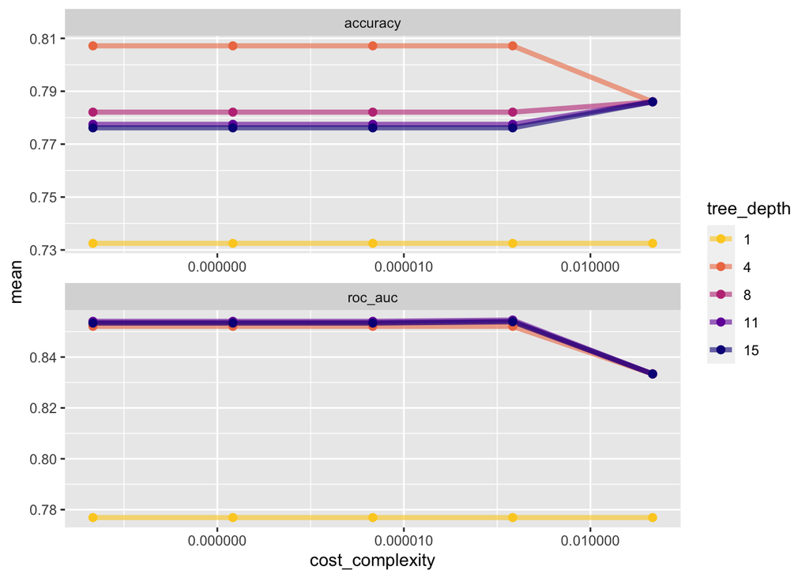

```r
tree_res %>%
  collect_metrics() %>%
  mutate(tree_depth = factor(tree_depth)) %>%
  ggplot(aes(cost_complexity, mean, color = tree_depth)) +
  geom_line(size = 1.5, alpha = 0.6) +
  geom_point(size = 2) +
  facet_wrap(~ .metric, scales = "free", nrow = 2) +
  scale_x_log10(labels = scales::label_number()) +
  scale_color_viridis_d(option = "plasma", begin = .9, end = 0)
```

We can see that our “stubbiest” tree, with a depth of 1, is the worst model according to both metrics and across all candidate values of cost_complexity. Our deepest tree, with a depth of 15, did better. However, the best tree seems to be between these values with a tree depth of 4. The show_best() function shows us the top 5 candidate models by default:

```r
tree_res %>%
  show_best("accuracy")
```

```
## # A tibble: 5 × 8
##   cost_complexity tree_depth .metric  .estimator  mean     n std_err .config
##             <dbl>      <int> <chr>    <chr>      <dbl> <int>   <dbl> <chr>
## 1    0.0000000001          4 accuracy binary     0.807    10  0.0119 Preprocess…
## 2    0.0000000178          4 accuracy binary     0.807    10  0.0119 Preprocess…
## 3    0.00000316            4 accuracy binary     0.807    10  0.0119 Preprocess…
## 4    0.000562              4 accuracy binary     0.807    10  0.0119 Preprocess…
## 5    0.1                   4 accuracy binary     0.786    10  0.0124 Preprocess…
```

```
#> # A tibble: 5 × 8
#>   cost_complexity tree_depth .metric  .estimator  mean     n std_err .config
#>             <dbl>      <int> <chr>    <chr>      <dbl> <int>   <dbl> <chr>
#> 1    0.0000000001          4 accuracy binary     0.807    10  0.0119 Preprocess…
#> 2    0.0000000178          4 accuracy binary     0.807    10  0.0119 Preprocess…
#> 3    0.00000316            4 accuracy binary     0.807    10  0.0119 Preprocess…
#> 4    0.000562              4 accuracy binary     0.807    10  0.0119 Preprocess…
#> 5    0.1                   4 accuracy binary     0.786    10  0.0124 Preprocess…
```

We can also use the select_best() function to pull out the single set of hyperparameter values for our best decision tree model:

```r
best_tree <- tree_res %>%
  select_best("accuracy")

best_tree
```

```
## # A tibble: 1 × 3
##   cost_complexity tree_depth .config
##             <dbl>      <int> <chr>
## 1    0.0000000001          4 Preprocessor1_Model06
```

```
#> # A tibble: 1 × 3
#>   cost_complexity tree_depth .config
#>             <dbl>      <int> <chr>
#> 1    0.0000000001          4 Preprocessor1_Model06
```

finalizing our model We can update (or “finalize”) our workflow object tree_wf with the values from select_best().

```r
final_wf <-
  tree_wf %>%
  finalize_workflow(best_tree)

final_wf
```

```
## ══ Workflow ════════════════════════════════════════════════════════════════════
## Preprocessor: Formula
## Model: decision_tree()
##
## ── Preprocessor ────────────────────────────────────────────────────────────────
## class ~ .
##
## ── Model ───────────────────────────────────────────────────────────────────────
## Decision Tree Model Specification (classification)
##
## Main Arguments:
##   cost_complexity = 1e-10
##   tree_depth = 4
##
## Computational engine: rpart
```

```
#> ══ Workflow ══════════════════════════════════════════════════════════
#> Preprocessor: Formula
#> Model: decision_tree()
#>
#> ── Preprocessor ──────────────────────────────────────────────────────
#> class ~ .
#>
#> ── Model ─────────────────────────────────────────────────────────────
#> Decision Tree Model Specification (classification)
#>
#> Main Arguments:
#>   cost_complexity = 1e-10
#>   tree_depth = 4
#>
#> Computational engine: rpart
```

last fit

Finally, let’s fit this final model to the training data and use our test data to estimate the model performance we expect to see with new data. We can use the function last_fit() with our finalized model; this function fits the finalized model on the full training data set and evaluates the finalized model on the testing data.

```r
final_fit <-
  final_wf %>%
  last_fit(cell_split)

final_fit %>%
  collect_metrics()
```

```
## # A tibble: 2 × 4
##   .metric  .estimator .estimate .config
##   <chr>    <chr>          <dbl> <chr>
## 1 accuracy binary         0.802 Preprocessor1_Model1
## 2 roc_auc  binary         0.840 Preprocessor1_Model1
```

```
#> # A tibble: 2 × 4
#>   .metric  .estimator .estimate .config
#>   <chr>    <chr>          <dbl> <chr>
#> 1 accuracy binary         0.802 Preprocessor1_Model1
#> 2 roc_auc  binary         0.840 Preprocessor1_Model1
```

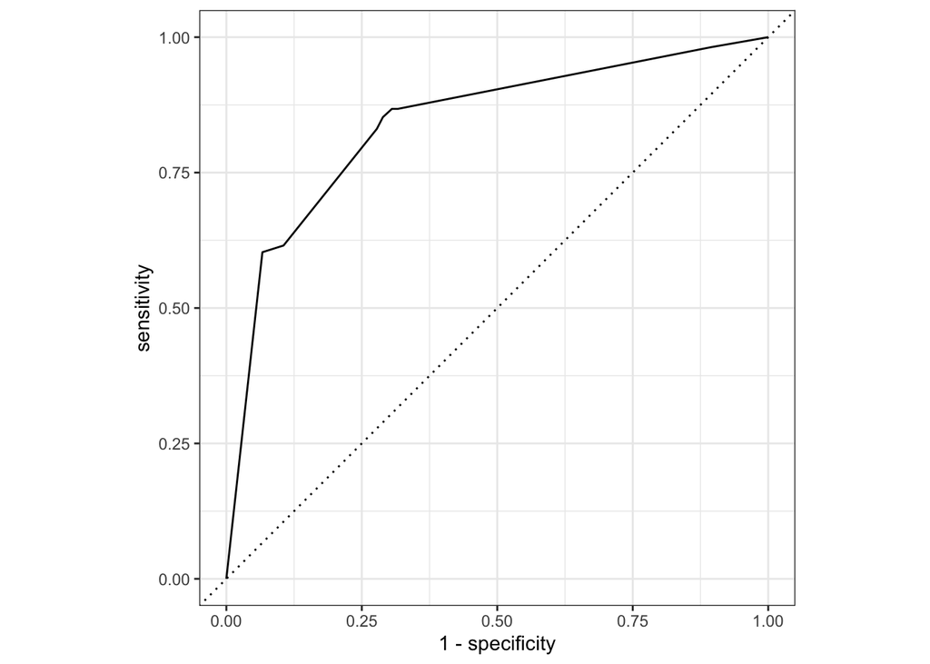

```r
final_fit %>%
  collect_predictions() %>%
  roc_curve(class, .pred_PS) %>%
  autoplot()
```

The final_fit object contains a finalized, fitted workflow that you can use for predicting on new data or further understanding the results. You may want to extract this object, using one of the extract_ helper functions.

```r
final_tree <- extract_workflow(final_fit)
final_tree
```

```
## ══ Workflow [trained] ══════════════════════════════════════════════════════════
## Preprocessor: Formula
## Model: decision_tree()
##
## ── Preprocessor ────────────────────────────────────────────────────────────────
## class ~ .
##
## ── Model ───────────────────────────────────────────────────────────────────────
## n= 1514
##
## node), split, n, loss, yval, (yprob)
##       * denotes terminal node
##
##  1) root 1514 539 PS (0.64398943 0.35601057)
##    2) total_inten_ch_2< 41732.5 642  33 PS (0.94859813 0.05140187)
##      4) shape_p_2_a_ch_1>=1.251801 631  27 PS (0.95721078 0.04278922) *
##      5) shape_p_2_a_ch_1< 1.251801 11   5 WS (0.45454545 0.54545455) *
##    3) total_inten_ch_2>=41732.5 872 366 WS (0.41972477 0.58027523)
##      6) fiber_width_ch_1< 11.37318 406 160 PS (0.60591133 0.39408867)
##       12) avg_inten_ch_1< 145.4883 293  85 PS (0.70989761 0.29010239) *
##       13) avg_inten_ch_1>=145.4883 113  38 WS (0.33628319 0.66371681)
##         26) total_inten_ch_3>=57919.5 33  10 PS (0.69696970 0.30303030) *
##         27) total_inten_ch_3< 57919.5 80  15 WS (0.18750000 0.81250000) *
##      7) fiber_width_ch_1>=11.37318 466 120 WS (0.25751073 0.74248927)
##       14) eq_ellipse_oblate_vol_ch_1>=1673.942 30   8 PS (0.73333333 0.26666667)
##         28) var_inten_ch_3>=41.10858 20   2 PS (0.90000000 0.10000000) *
##         29) var_inten_ch_3< 41.10858 10   4 WS (0.40000000 0.60000000) *
##       15) eq_ellipse_oblate_vol_ch_1< 1673.942 436  98 WS (0.22477064 0.77522936) *
```

```
#> ══ Workflow [trained] ════════════════════════════════════════════════
#> Preprocessor: Formula
#> Model: decision_tree()
#>
#> ── Preprocessor ──────────────────────────────────────────────────────
#> class ~ .
#>
#> ── Model ─────────────────────────────────────────────────────────────
#> n= 1514
#>
#> node), split, n, loss, yval, (yprob)
#>       * denotes terminal node
#>
#>  1) root 1514 539 PS (0.64398943 0.35601057)
#>    2) total_inten_ch_2< 41732.5 642  33 PS (0.94859813 0.05140187)
#>      4) shape_p_2_a_ch_1>=1.251801 631  27 PS (0.95721078 0.04278922) *
#>      5) shape_p_2_a_ch_1< 1.251801 11   5 WS (0.45454545 0.54545455) *
#>    3) total_inten_ch_2>=41732.5 872 366 WS (0.41972477 0.58027523)
#>      6) fiber_width_ch_1< 11.37318 406 160 PS (0.60591133 0.39408867)
#>       12) avg_inten_ch_1< 145.4883 293  85 PS (0.70989761 0.29010239) *
#>       13) avg_inten_ch_1>=145.4883 113  38 WS (0.33628319 0.66371681)
#>         26) total_inten_ch_3>=57919.5 33  10 PS (0.69696970 0.30303030) *
#>         27) total_inten_ch_3< 57919.5 80  15 WS (0.18750000 0.81250000) *
#>      7) fiber_width_ch_1>=11.37318 466 120 WS (0.25751073 0.74248927)
#>       14) eq_ellipse_oblate_vol_ch_1>=1673.942 30   8 PS (0.73333333 0.26666667)
#>         28) var_inten_ch_3>=41.10858 20   2 PS (0.90000000 0.10000000) *
#>         29) var_inten_ch_3< 41.10858 10   4 WS (0.40000000 0.60000000) *
#>       15) eq_ellipse_oblate_vol_ch_1< 1673.942 436  98 WS (0.22477064 0.77522936) *
```

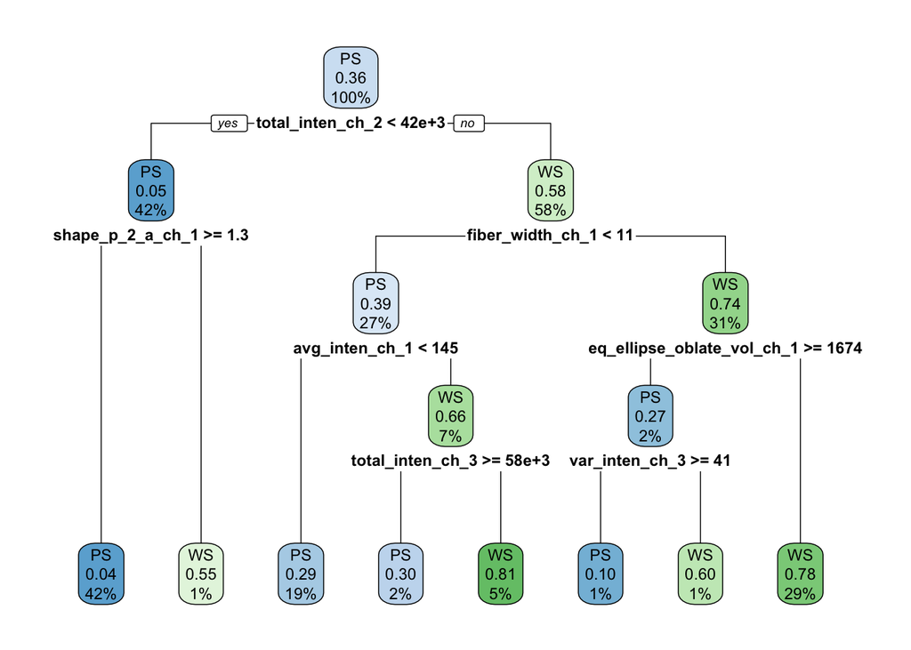

```r
final_tree %>%
  extract_fit_engine() %>%
  rpart.plot(roundint = FALSE)
```

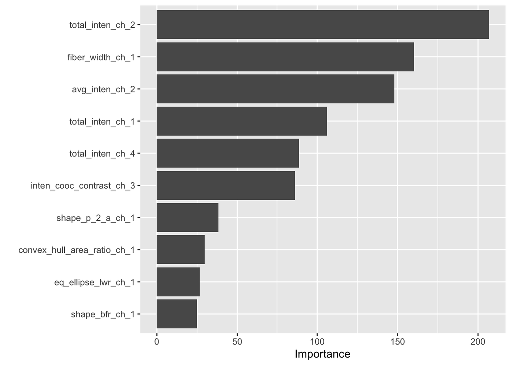

```r
library(vip)

final_tree %>%
  extract_fit_parsnip() %>%
  vip()
```

These are the automated image analysis measurements that are the most important in driving segmentation quality predictions.

We leave it to the reader to explore whether you can tune a different decision tree hyperparameter. You can explore the reference docs, or use the args() function to see which parsnip object arguments are available:

```r
args(decision_tree)
```

```
## function (mode = "unknown", engine = "rpart", cost_complexity = NULL,
##     tree_depth = NULL, min_n = NULL)
## NULL
```

```
#> function (mode = "unknown", engine = "rpart", cost_complexity = NULL,
#>     tree_depth = NULL, min_n = NULL)
#> NULL
```

## A predictive modeling case study

```r
library(tidymodels)

# Helper packages
library(readr)       # for importing data
library(vip)         # for variable importance plots
```

the hotel booking data Let’s use hotel bookings data from Antonio, Almeida, and Nunes (2019) to predict which hotel stays included children and/or babies, based on the other characteristics of the stays such as which hotel the guests stay at, how much they pay, etc. This was also a #TidyTuesday dataset with a data dictionary you may want to look over to learn more about the variables. We’ll use a slightly edited version of the dataset for this case study.

To start, let’s read our hotel data into R, which we’ll do by providing readr::read_csv() with a url where our CSV data is located (“https://tidymodels.org/start/case-study/hotels.csv”):

```r
library(tidymodels)
library(readr)

hotels <-
  read_csv('https://tidymodels.org/start/case-study/hotels.csv') %>%
  mutate(across(where(is.character), as.factor))
dim(hotels)
```

```
## [1] 50000    23
```

```
#> [1] 50000    23
```

In the original paper, the authors caution that the distribution of many variables (such as number of adults/children, room type, meals bought, country of origin of the guests, and so forth) is different for hotel stays that were canceled versus not canceled. This makes sense because much of that information is gathered (or gathered again more accurately) when guests check in for their stay, so canceled bookings are likely to have more missing data than non-canceled bookings, and/or to have different characteristics when data is not missing. Given this, it is unlikely that we can reliably detect meaningful differences between guests who cancel their bookings and those who do not with this dataset. To build our models here, we have already filtered the data to include only the bookings that did not cancel, so we’ll be analyzing hotel stays only.

```r
glimpse(hotels)
```

```
## Rows: 50,000
## Columns: 23
## $ hotel                          <fct> City_Hotel, City_Hotel, Resort_Hotel, R…
## $ lead_time                      <dbl> 217, 2, 95, 143, 136, 67, 47, 56, 80, 6…
## $ stays_in_weekend_nights        <dbl> 1, 0, 2, 2, 1, 2, 0, 0, 0, 2, 1, 0, 1, …
## $ stays_in_week_nights           <dbl> 3, 1, 5, 6, 4, 2, 2, 3, 4, 2, 2, 1, 2, …
## $ adults                         <dbl> 2, 2, 2, 2, 2, 2, 2, 0, 2, 2, 2, 1, 2, …
## $ children                       <fct> none, none, none, none, none, none, chi…
## $ meal                           <fct> BB, BB, BB, HB, HB, SC, BB, BB, BB, BB,…
## $ country                        <fct> DEU, PRT, GBR, ROU, PRT, GBR, ESP, ESP,…
## $ market_segment                 <fct> Offline_TA/TO, Direct, Online_TA, Onlin…
## $ distribution_channel           <fct> TA/TO, Direct, TA/TO, TA/TO, Direct, TA…
## $ is_repeated_guest              <dbl> 0, 0, 0, 0, 0, 0, 0, 0, 0, 0, 0, 0, 0, …
## $ previous_cancellations         <dbl> 0, 0, 0, 0, 0, 0, 0, 0, 0, 0, 0, 0, 0, …
## $ previous_bookings_not_canceled <dbl> 0, 0, 0, 0, 0, 0, 0, 0, 0, 0, 0, 0, 0, …
## $ reserved_room_type             <fct> A, D, A, A, F, A, C, B, D, A, A, D, A, …
## $ assigned_room_type             <fct> A, K, A, A, F, A, C, A, D, A, D, D, A, …
## $ booking_changes                <dbl> 0, 0, 2, 0, 0, 0, 0, 0, 0, 0, 0, 0, 0, …
## $ deposit_type                   <fct> No_Deposit, No_Deposit, No_Deposit, No_…
## $ days_in_waiting_list           <dbl> 0, 0, 0, 0, 0, 0, 0, 0, 0, 0, 0, 0, 0, …
## $ customer_type                  <fct> Transient-Party, Transient, Transient, …
## $ average_daily_rate             <dbl> 80.75, 170.00, 8.00, 81.00, 157.60, 49.…
## $ required_car_parking_spaces    <fct> none, none, none, none, none, none, non…
## $ total_of_special_requests      <dbl> 1, 3, 2, 1, 4, 1, 1, 1, 1, 1, 0, 1, 0, …
## $ arrival_date                   <date> 2016-09-01, 2017-08-25, 2016-11-19, 20…
```

```
#> Rows: 50,000
#> Columns: 23
#> $ hotel                          <fct> City_Hotel, City_Hotel, Resort_Hotel, R…
#> $ lead_time                      <dbl> 217, 2, 95, 143, 136, 67, 47, 56, 80, 6…
#> $ stays_in_weekend_nights        <dbl> 1, 0, 2, 2, 1, 2, 0, 0, 0, 2, 1, 0, 1, …
#> $ stays_in_week_nights           <dbl> 3, 1, 5, 6, 4, 2, 2, 3, 4, 2, 2, 1, 2, …
#> $ adults                         <dbl> 2, 2, 2, 2, 2, 2, 2, 0, 2, 2, 2, 1, 2, …
#> $ children                       <fct> none, none, none, none, none, none, chi…
#> $ meal                           <fct> BB, BB, BB, HB, HB, SC, BB, BB, BB, BB,…
#> $ country                        <fct> DEU, PRT, GBR, ROU, PRT, GBR, ESP, ESP,…
#> $ market_segment                 <fct> Offline_TA/TO, Direct, Online_TA, Onlin…
#> $ distribution_channel           <fct> TA/TO, Direct, TA/TO, TA/TO, Direct, TA…
#> $ is_repeated_guest              <dbl> 0, 0, 0, 0, 0, 0, 0, 0, 0, 0, 0, 0, 0, …
#> $ previous_cancellations         <dbl> 0, 0, 0, 0, 0, 0, 0, 0, 0, 0, 0, 0, 0, …
#> $ previous_bookings_not_canceled <dbl> 0, 0, 0, 0, 0, 0, 0, 0, 0, 0, 0, 0, 0, …
#> $ reserved_room_type             <fct> A, D, A, A, F, A, C, B, D, A, A, D, A, …
#> $ assigned_room_type             <fct> A, K, A, A, F, A, C, A, D, A, D, D, A, …
#> $ booking_changes                <dbl> 0, 0, 2, 0, 0, 0, 0, 0, 0, 0, 0, 0, 0, …
#> $ deposit_type                   <fct> No_Deposit, No_Deposit, No_Deposit, No_…
#> $ days_in_waiting_list           <dbl> 0, 0, 0, 0, 0, 0, 0, 0, 0, 0, 0, 0, 0, …
#> $ customer_type                  <fct> Transient-Party, Transient, Transient, …
#> $ average_daily_rate             <dbl> 80.75, 170.00, 8.00, 81.00, 157.60, 49.…
#> $ required_car_parking_spaces    <fct> none, none, none, none, none, none, non…
#> $ total_of_special_requests      <dbl> 1, 3, 2, 1, 4, 1, 1, 1, 1, 1, 0, 1, 0, …
#> $ arrival_date                   <date> 2016-09-01, 2017-08-25, 2016-11-19, 20…
```

We will build a model to predict which actual hotel stays included children and/or babies, and which did not. Our outcome variable children is a factor variable with two levels:

```r
hotels %>%
  count(children) %>%
  mutate(prop = n/sum(n))
```

```
## # A tibble: 2 × 3
##   children     n   prop
##   <fct>    <int>  <dbl>
## 1 children  4038 0.0808
## 2 none     45962 0.919
```

```
#> # A tibble: 2 × 3
#>   children     n   prop
#>   <fct>    <int>  <dbl>
#> 1 children  4038 0.0808
#> 2 none     45962 0.919
```

data splitting and resampling For a data splitting strategy, let’s reserve 25% of the stays to the test set. As in our Evaluate your model with resampling article, we know our outcome variable children is pretty imbalanced so we’ll use a stratified random sample:

```r
set.seed(123)
splits      <- initial_split(hotels, strata = children)

hotel_other <- training(splits)
hotel_test  <- testing(splits)

# training set proportions by children
hotel_other %>%
  count(children) %>%
  mutate(prop = n/sum(n))
```

```
## # A tibble: 2 × 3
##   children     n   prop
##   <fct>    <int>  <dbl>
## 1 children  3027 0.0807
## 2 none     34473 0.919
```

```
#> # A tibble: 2 × 3
#>   children     n   prop
#>   <fct>    <int>  <dbl>
#> 1 children  3027 0.0807
#> 2 none     34473 0.919
```

```r
# test set proportions by children
hotel_test  %>%
  count(children) %>%
  mutate(prop = n/sum(n))
```

```
## # A tibble: 2 × 3
##   children     n   prop
##   <fct>    <int>  <dbl>
## 1 children  1011 0.0809
## 2 none     11489 0.919
```

```
#> # A tibble: 2 × 3
#>   children     n   prop
#>   <fct>    <int>  <dbl>
#> 1 children  1011 0.0809
#> 2 none     11489 0.919
```

In our articles so far, we’ve relied on 10-fold cross-validation as the primary resampling method using rsample::vfold_cv(). This has created 10 different resamples of the training set (which we further split into analysis and assessment sets), producing 10 different performance metrics that we then aggregated.

For this case study, rather than using multiple iterations of resampling, let’s create a single resample called a validation set. In tidymodels, a validation set is treated as a single iteration of resampling. This will be a split from the 37,500 stays that were not used for testing, which we called hotel_other. This split creates two new datasets:

the set held out for the purpose of measuring performance, called the validation set, and the remaining data used to fit the model, called the training set.

We’ll use the validation_split() function to allocate 20% of the hotel_other stays to the validation set and 30,000 stays to the training set. This means that our model performance metrics will be computed on a single set of 7,500 hotel stays. This is fairly large, so the amount of data should provide enough precision to be a reliable indicator for how well each model predicts the outcome with a single iteration of resampling.

```r
set.seed(234)
val_set <- validation_split(hotel_other,
                            strata = children,
                            prop = 0.80)
val_set
```

```
## # Validation Set Split (0.8/0.2)  using stratification
## # A tibble: 1 × 2
##   splits               id
##   <list>               <chr>
## 1 <split [30000/7500]> validation
```

```
#> # Validation Set Split (0.8/0.2)  using stratification
#> # A tibble: 1 × 2
#>   splits               id
#>   <list>               <chr>
#> 1 <split [30000/7500]> validation
```

This function, like initial_split(), has the same strata argument, which uses stratified sampling to create the resample. This means that we’ll have roughly the same proportions of hotel stays with and without children in our new validation and training sets, as compared to the original hotel_other proportions

A first model: penalized logistic regression ince our outcome variable children is categorical, logistic regression would be a good first model to start. Let’s use a model that can perform feature selection during training. The glmnet R package fits a generalized linear model via penalized maximum likelihood. This method of estimating the logistic regression slope parameters uses a penalty on the process so that less relevant predictors are driven towards a value of zero. One of the glmnet penalization methods, called the lasso method, can actually set the predictor slopes to zero if a large enough penalty is used

build the model

```r
lr_mod <-
  logistic_reg(penalty = tune(), mixture = 1) %>%
  set_engine("glmnet")
```

create the recipe step_dummy() converts characters or factors (i.e., nominal variables) into one or more numeric binary model terms for the levels of the original data. step_zv() removes indicator variables that only contain a single unique value (e.g. all zeros). This is important because, for penalized models, the predictors should be centered and scaled. step_normalize() centers and scales numeric variables.

```r
holidays <- c("AllSouls", "AshWednesday", "ChristmasEve", "Easter",
              "ChristmasDay", "GoodFriday", "NewYearsDay", "PalmSunday")

lr_recipe <-
  recipe(children ~ ., data = hotel_other) %>%
  step_date(arrival_date) %>%
  step_holiday(arrival_date, holidays = holidays) %>%
  step_rm(arrival_date) %>%
  step_dummy(all_nominal_predictors()) %>%
  step_zv(all_predictors()) %>%
  step_normalize(all_predictors())
```

create the workflow As we introduced in Preprocess your data with recipes, let’s bundle the model and recipe into a single workflow() object to make management of the R objects easier:

```r
lr_workflow <-
  workflow() %>%
  add_model(lr_mod) %>%
  add_recipe(lr_recipe)
```

create the grid for tuning Before we fit this model, we need to set up a grid of penalty values to tune. In our Tune model parameters article, we used dials::grid_regular() to create an expanded grid based on a combination of two hyperparameters. Since we have only one hyperparameter to tune here, we can set the grid up manually using a one-column tibble with 30 candidate values:

```r
lr_reg_grid <- tibble(penalty = 10^seq(-4, -1, length.out = 30))

lr_reg_grid %>% top_n(-5) # lowest penalty values
```

```
## # A tibble: 5 × 1
##    penalty
##      <dbl>
## 1 0.0001
## 2 0.000127
## 3 0.000161
## 4 0.000204
## 5 0.000259
```

```
#> # A tibble: 5 × 1
#>    penalty
#>      <dbl>
#> 1 0.0001
#> 2 0.000127
#> 3 0.000161
#> 4 0.000204
#> 5 0.000259
```

```r
lr_reg_grid %>% top_n(5)  # highest penalty values
```

```
## # A tibble: 5 × 1
##   penalty
##     <dbl>
## 1  0.0386
## 2  0.0489
## 3  0.0621
## 4  0.0788
## 5  0.1
```

```
#> # A tibble: 5 × 1
#>   penalty
#>     <dbl>
#> 1  0.0386
#> 2  0.0489
#> 3  0.0621
#> 4  0.0788
#> 5  0.1
```

train and tune the model

Let’s use tune::tune_grid() to train these 30 penalized logistic regression models. We’ll also save the validation set predictions (via the call to control_grid()) so that diagnostic information can be available after the model fit. The area under the ROC curve will be used to quantify how well the model performs across a continuum of event thresholds (recall that the event rate—the proportion of stays including children— is very low for these data).

```r
lr_res <-
  lr_workflow %>%
  tune_grid(val_set,
            grid = lr_reg_grid,
            control = control_grid(save_pred = TRUE),
            metrics = metric_set(roc_auc))
```

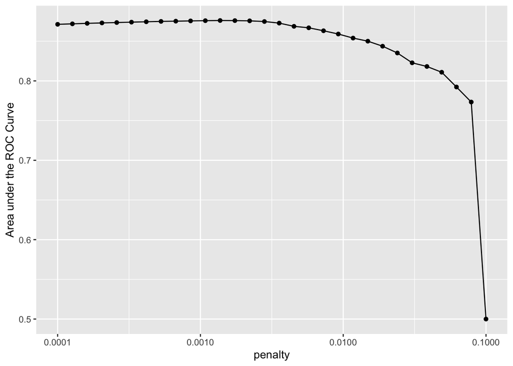

```r
lr_plot <-
  lr_res %>%
  collect_metrics() %>%
  ggplot(aes(x = penalty, y = mean)) +
  geom_point() +
  geom_line() +
  ylab("Area under the ROC Curve") +
  scale_x_log10(labels = scales::label_number())

lr_plot
```

This plots shows us that model performance is generally better at the smaller penalty values. This suggests that the majority of the predictors are important to the model. We also see a steep drop in the area under the ROC curve towards the highest penalty values. This happens because a large enough penalty will remove all predictors from the model, and not surprisingly predictive accuracy plummets with no predictors in the model (recall that an ROC AUC value of 0.50 means that the model does no better than chance at predicting the correct class).

Our model performance seems to plateau at the smaller penalty values, so going by the roc_auc metric alone could lead us to multiple options for the “best” value for this hyperparameter:

```r
top_models <-
  lr_res %>%
  show_best("roc_auc", n = 15) %>%
  arrange(penalty)
top_models
```

```
## # A tibble: 15 × 7
##     penalty .metric .estimator  mean     n std_err .config
##       <dbl> <chr>   <chr>      <dbl> <int>   <dbl> <chr>
##  1 0.000127 roc_auc binary     0.872     1      NA Preprocessor1_Model02
##  2 0.000161 roc_auc binary     0.872     1      NA Preprocessor1_Model03
##  3 0.000204 roc_auc binary     0.873     1      NA Preprocessor1_Model04
##  4 0.000259 roc_auc binary     0.873     1      NA Preprocessor1_Model05
##  5 0.000329 roc_auc binary     0.874     1      NA Preprocessor1_Model06
##  6 0.000418 roc_auc binary     0.874     1      NA Preprocessor1_Model07
##  7 0.000530 roc_auc binary     0.875     1      NA Preprocessor1_Model08
##  8 0.000672 roc_auc binary     0.875     1      NA Preprocessor1_Model09
##  9 0.000853 roc_auc binary     0.876     1      NA Preprocessor1_Model10
## 10 0.00108  roc_auc binary     0.876     1      NA Preprocessor1_Model11
## 11 0.00137  roc_auc binary     0.876     1      NA Preprocessor1_Model12
## 12 0.00174  roc_auc binary     0.876     1      NA Preprocessor1_Model13
## 13 0.00221  roc_auc binary     0.876     1      NA Preprocessor1_Model14
## 14 0.00281  roc_auc binary     0.875     1      NA Preprocessor1_Model15
## 15 0.00356  roc_auc binary     0.873     1      NA Preprocessor1_Model16
```

```
#> # A tibble: 15 × 7
#>     penalty .metric .estimator  mean     n std_err .config
#>       <dbl> <chr>   <chr>      <dbl> <int>   <dbl> <chr>
#>  1 0.000127 roc_auc binary     0.872     1      NA Preprocessor1_Model02
#>  2 0.000161 roc_auc binary     0.872     1      NA Preprocessor1_Model03
#>  3 0.000204 roc_auc binary     0.873     1      NA Preprocessor1_Model04
#>  4 0.000259 roc_auc binary     0.873     1      NA Preprocessor1_Model05
#>  5 0.000329 roc_auc binary     0.874     1      NA Preprocessor1_Model06
#>  6 0.000418 roc_auc binary     0.874     1      NA Preprocessor1_Model07
#>  7 0.000530 roc_auc binary     0.875     1      NA Preprocessor1_Model08
#>  8 0.000672 roc_auc binary     0.875     1      NA Preprocessor1_Model09
#>  9 0.000853 roc_auc binary     0.876     1      NA Preprocessor1_Model10
#> 10 0.00108  roc_auc binary     0.876     1      NA Preprocessor1_Model11
#> 11 0.00137  roc_auc binary     0.876     1      NA Preprocessor1_Model12
#> 12 0.00174  roc_auc binary     0.876     1      NA Preprocessor1_Model13
#> 13 0.00221  roc_auc binary     0.876     1      NA Preprocessor1_Model14
#> 14 0.00281  roc_auc binary     0.875     1      NA Preprocessor1_Model15
#> 15 0.00356  roc_auc binary     0.873     1      NA Preprocessor1_Model16
```

```r
lr_best <-
  lr_res %>%
  collect_metrics() %>%
  arrange(penalty) %>%
  slice(12)
lr_best
```

```
## # A tibble: 1 × 7
##   penalty .metric .estimator  mean     n std_err .config
##     <dbl> <chr>   <chr>      <dbl> <int>   <dbl> <chr>
## 1 0.00137 roc_auc binary     0.876     1      NA Preprocessor1_Model12
```

```
#> # A tibble: 1 × 7
#>   penalty .metric .estimator  mean     n std_err .config
#>     <dbl> <chr>   <chr>      <dbl> <int>   <dbl> <chr>
#> 1 0.00137 roc_auc binary     0.876     1      NA Preprocessor1_Model12
```

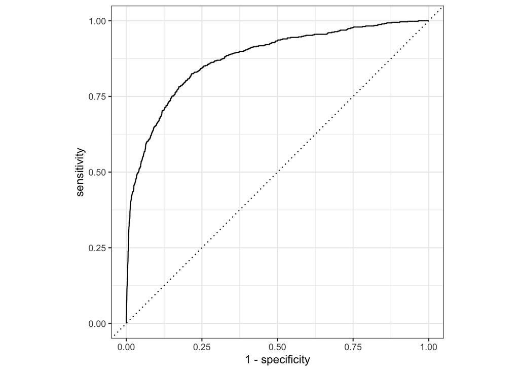

```r
lr_auc <-
  lr_res %>%
  collect_predictions(parameters = lr_best) %>%
  roc_curve(children, .pred_children) %>%
  mutate(model = "Logistic Regression")

autoplot(lr_auc)
```

The level of performance generated by this logistic regression model is good, but not groundbreaking. Perhaps the linear nature of the prediction equation is too limiting for this data set. As a next step, we might consider a highly non-linear model generated using a tree-based ensemble method.

a second model: tree-based ensmble

An effective and low-maintenance modeling technique is a random forest. This model was also used in our Evaluate your model with resampling article. Compared to logistic regression, a random forest model is more flexible. A random forest is an ensemble model typically made up of thousands of decision trees, where each individual tree sees a slightly different version of the training data and learns a sequence of splitting rules to predict new data. Each tree is non-linear, and aggregating across trees makes random forests also non-linear but more robust and stable compared to individual trees. Tree-based models like random forests require very little preprocessing and can effectively handle many types of predictors (sparse, skewed, continuous, categorical, etc.

Build the model and improve training time

```r
cores <- parallel::detectCores()
cores
```

```
## [1] 16
```

```
#> [1] 10
```

```r
rf_mod <-
  rand_forest(mtry = tune(), min_n = tune(), trees = 1000) %>%
  set_engine("ranger", num.threads = cores) %>%
  set_mode("classification")
```

create the recipe and workflow Unlike penalized logistic regression models, random forest models do not require dummy or normalized predictor variables. Nevertheless, we want to do some feature engineering again with our arrival_date variable. As before, the date predictor is engineered so that the random forest model does not need to work hard to tease these potential patterns from the data.

```r
rf_recipe <-
  recipe(children ~ ., data = hotel_other) %>%
  step_date(arrival_date) %>%
  step_holiday(arrival_date) %>%
  step_rm(arrival_date)
```

Adding this recipe to our parsnip model gives us a new workflow for predicting whether a hotel stay included children and/or babies as guests with a random forest:

```r
rf_workflow <-
  workflow() %>%
  add_model(rf_mod) %>%
  add_recipe(rf_recipe)
```

train and tune the model When we set up our parsnip model, we chose two hyperparameters for tuning:

```r
rf_mod
```

```
## Random Forest Model Specification (classification)
##
## Main Arguments:
##   mtry = tune()
##   trees = 1000
##   min_n = tune()
##
## Engine-Specific Arguments:
##   num.threads = cores
##
## Computational engine: ranger
```

```
#> Random Forest Model Specification (classification)
#>
#> Main Arguments:
#>   mtry = tune()
#>   trees = 1000
#>   min_n = tune()
#>
#> Engine-Specific Arguments:
#>   num.threads = cores
#>
#> Computational engine: ranger
```

```r
# show what will be tuned
extract_parameter_set_dials(rf_mod)
```

```
## Collection of 2 parameters for tuning
##
##  identifier  type    object
##        mtry  mtry nparam[?]
##       min_n min_n nparam[+]
##
## Model parameters needing finalization:
##    # Randomly Selected Predictors ('mtry')
##
## See `?dials::finalize` or `?dials::update.parameters` for more information.
```

```
#> Collection of 2 parameters for tuning
#>
#>  identifier  type    object
#>        mtry  mtry nparam[?]
#>       min_n min_n nparam[+]
#>
#> Model parameters needing finalization:
#>    # Randomly Selected Predictors ('mtry')
#>
#> See `?dials::finalize` or `?dials::update.parameters` for more information.
```

The mtry hyperparameter sets the number of predictor variables that each node in the decision tree “sees” and can learn about, so it can range from 1 to the total number of features present; when mtry = all possible features, the model is the same as bagging decision trees. The min_n hyperparameter sets the minimum n to split at any node.

We will use a space-filling design to tune, with 25 candidate models:

```r
set.seed(345)
rf_res <-
  rf_workflow %>%
  tune_grid(val_set,
            grid = 25,
            control = control_grid(save_pred = TRUE),
            metrics = metric_set(roc_auc))
```

```
## i Creating pre-processing data to finalize unknown parameter: mtry
```

```
#> i Creating pre-processing data to finalize unknown parameter: mtry
```

The message printed above “Creating pre-processing data to finalize unknown parameter: mtry” is related to the size of the data set. Since mtry depends on the number of predictors in the data set, tune_grid() determines the upper bound for mtry once it receives the data.

Here are our top 5 random forest models, out of the 25 candidates:

```r
rf_res %>%
  show_best(metric = "roc_auc")
```

```
## # A tibble: 5 × 8
##    mtry min_n .metric .estimator  mean     n std_err .config
##   <int> <int> <chr>   <chr>      <dbl> <int>   <dbl> <chr>
## 1     8     7 roc_auc binary     0.926     1      NA Preprocessor1_Model13
## 2    12     7 roc_auc binary     0.926     1      NA Preprocessor1_Model01
## 3    13     4 roc_auc binary     0.925     1      NA Preprocessor1_Model05
## 4     9    12 roc_auc binary     0.924     1      NA Preprocessor1_Model19
## 5     6    18 roc_auc binary     0.924     1      NA Preprocessor1_Model24
```

```
#> # A tibble: 5 × 8
#>    mtry min_n .metric .estimator  mean     n std_err .config
#>   <int> <int> <chr>   <chr>      <dbl> <int>   <dbl> <chr>
#> 1     8     7 roc_auc binary     0.926     1      NA Preprocessor1_Model13
#> 2    12     7 roc_auc binary     0.926     1      NA Preprocessor1_Model01
#> 3    13     4 roc_auc binary     0.925     1      NA Preprocessor1_Model05
#> 4     9    12 roc_auc binary     0.924     1      NA Preprocessor1_Model19
#> 5     6    18 roc_auc binary     0.924     1      NA Preprocessor1_Model24
```

Right away, we see that these values for area under the ROC look more promising than our top model using penalized logistic regression, which yielded an ROC AUC of 0.876.

Plotting the results of the tuning process highlights that both mtry (number of predictors at each node) and min_n (minimum number of data points required to keep splitting) should be fairly small to optimize performance. However, the range of the y-axis indicates that the model is very robust to the choice of these parameter values — all but one of the ROC AUC values are greater than 0.90.

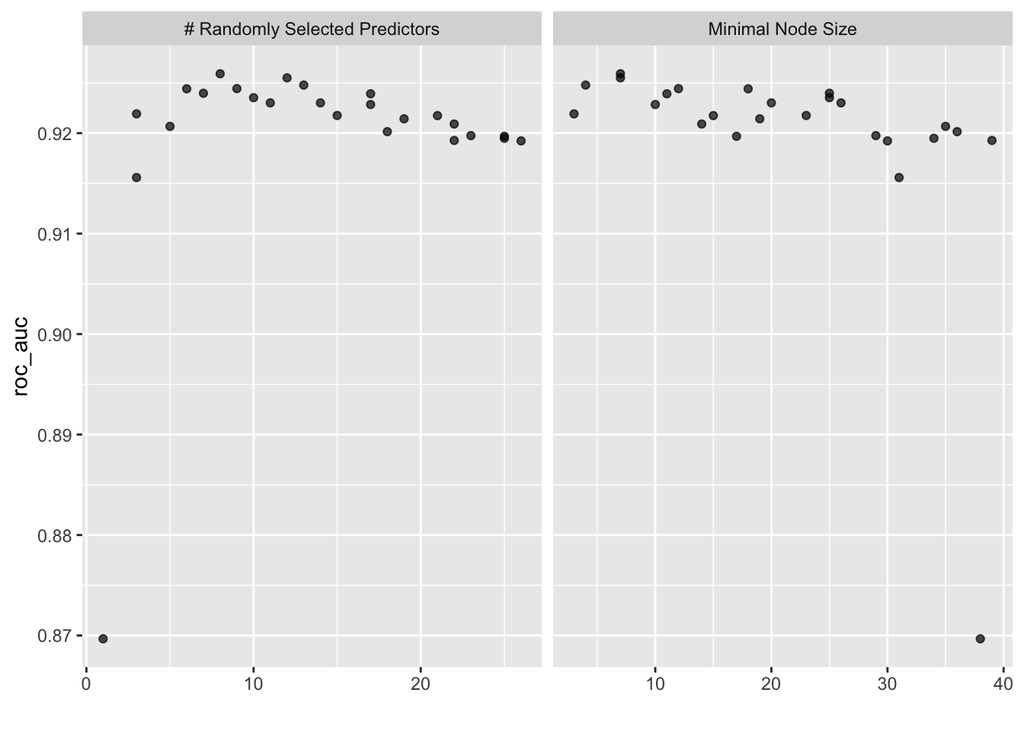

```r
autoplot(rf_res)
```

```r
rf_best <-
  rf_res %>%
  select_best(metric = "roc_auc")
rf_best
```

```
## # A tibble: 1 × 3
##    mtry min_n .config
##   <int> <int> <chr>
## 1     8     7 Preprocessor1_Model13
```

```
#> # A tibble: 1 × 3
#>    mtry min_n .config
#>   <int> <int> <chr>
#> 1     8     7 Preprocessor1_Model13
```

To calculate the data needed to plot the ROC curve, we use collect_predictions(). This is only possible after tuning with control_grid(save_pred = TRUE). In the output, you can see the two columns that hold our class probabilities for predicting hotel stays including and not including children.

```r
rf_res %>%
  collect_predictions()
```

```
## # A tibble: 187,500 × 8
##    id         .pred_children .pred_none  .row  mtry min_n children .config
##    <chr>               <dbl>      <dbl> <int> <int> <int> <fct>    <chr>
##  1 validation        0.152        0.848    13    12     7 none     Preprocessor…
##  2 validation        0.0302       0.970    20    12     7 none     Preprocessor…
##  3 validation        0.513        0.487    22    12     7 children Preprocessor…
##  4 validation        0.0103       0.990    23    12     7 none     Preprocessor…
##  5 validation        0.0111       0.989    31    12     7 none     Preprocessor…
##  6 validation        0            1        38    12     7 none     Preprocessor…
##  7 validation        0            1        39    12     7 none     Preprocessor…
##  8 validation        0.00325      0.997    50    12     7 none     Preprocessor…
##  9 validation        0.0241       0.976    54    12     7 none     Preprocessor…
## 10 validation        0.0441       0.956    57    12     7 children Preprocessor…
## # … with 187,490 more rows
## # ℹ Use `print(n = ...)` to see more rows
```

```
#> # A tibble: 187,500 × 8
#>   id         .pred_children .pred_none  .row  mtry min_n children .config
#>   <chr>               <dbl>      <dbl> <int> <int> <int> <fct>    <chr>
#> 1 validation         0.152       0.848    13    12     7 none     Preprocessor1…
#> 2 validation         0.0302      0.970    20    12     7 none     Preprocessor1…
#> 3 validation         0.513       0.487    22    12     7 children Preprocessor1…
#> 4 validation         0.0103      0.990    23    12     7 none     Preprocessor1…
#> 5 validation         0.0111      0.989    31    12     7 none     Preprocessor1…
#> # … with 187,495 more rows
```

To filter the predictions for only our best random forest model, we can use the parameters argument and pass it our tibble with the best hyperparameter values from tuning, which we called rf_best:

```r
rf_auc <-
  rf_res %>%
  collect_predictions(parameters = rf_best) %>%
  roc_curve(children, .pred_children) %>%
  mutate(model = "Random Forest")
```

Now, we can compare the validation set ROC curves for our top penalized logistic regression model and random forest model:

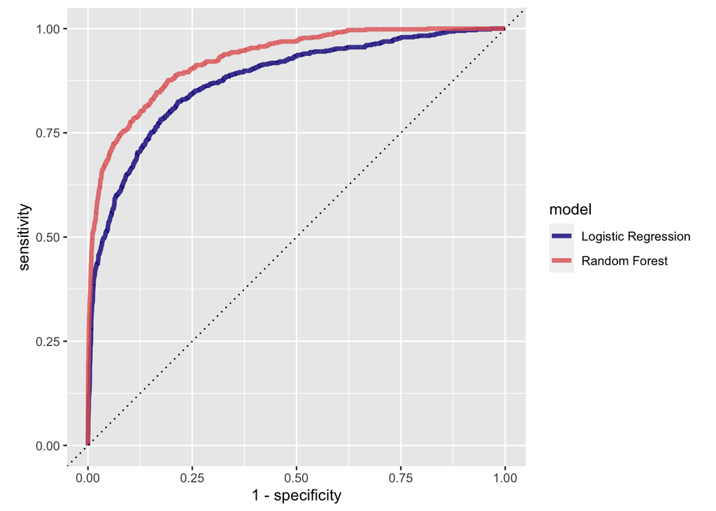

```r
bind_rows(rf_auc, lr_auc) %>%
  ggplot(aes(x = 1 - specificity, y = sensitivity, col = model)) +
  geom_path(lwd = 1.5, alpha = 0.8) +
  geom_abline(lty = 3) +
  coord_equal() +
  scale_color_viridis_d(option = "plasma", end = .6)
```

the last fit

Our goal was to predict which hotel stays included children and/or babies. The random forest model clearly performed better than the penalized logistic regression model, and would be our best bet for predicting hotel stays with and without children. After selecting our best model and hyperparameter values, our last step is to fit the final model on all the rows of data not originally held out for testing (both the training and the validation sets combined), and then evaluate the model performance one last time with the held-out test set.

We’ll start by building our parsnip model object again from scratch. We take our best hyperparameter values from our random forest model. When we set the engine, we add a new argument: importance = “impurity”. This will provide variable importance scores for this last model, which gives some insight into which predictors drive model performance.

```r
# the last model
last_rf_mod <-
  rand_forest(mtry = 8, min_n = 7, trees = 1000) %>%
  set_engine("ranger", num.threads = cores, importance = "impurity") %>%
  set_mode("classification")

# the last workflow
last_rf_workflow <-
  rf_workflow %>%
  update_model(last_rf_mod)

# the last fit
set.seed(345)
last_rf_fit <-
  last_rf_workflow %>%
  last_fit(splits)

last_rf_fit
```

```
## # Resampling results
## # Manual resampling
## # A tibble: 1 × 6
##   splits                id               .metrics .notes   .predict…¹ .workflow
##   <list>                <chr>            <list>   <list>   <list>     <list>
## 1 <split [37500/12500]> train/test split <tibble> <tibble> <tibble>   <workflow>
## # … with abbreviated variable name ¹.predictions
```

```
#> # Resampling results
#> # Manual resampling
#> # A tibble: 1 × 6
#>   splits                id             .metrics .notes   .predictions .workflow
#>   <list>                <chr>          <list>   <list>   <list>       <list>
#> 1 <split [37500/12500]> train/test sp… <tibble> <tibble> <tibble>     <workflow>
```

```r
last_rf_fit %>%
  collect_metrics()
```

```
## # A tibble: 2 × 4
##   .metric  .estimator .estimate .config
##   <chr>    <chr>          <dbl> <chr>
## 1 accuracy binary         0.946 Preprocessor1_Model1
## 2 roc_auc  binary         0.923 Preprocessor1_Model1
```

```
#> # A tibble: 2 × 4
#>   .metric  .estimator .estimate .config
#>   <chr>    <chr>          <dbl> <chr>
#> 1 accuracy binary         0.946 Preprocessor1_Model1
#> 2 roc_auc  binary         0.923 Preprocessor1_Model1
```

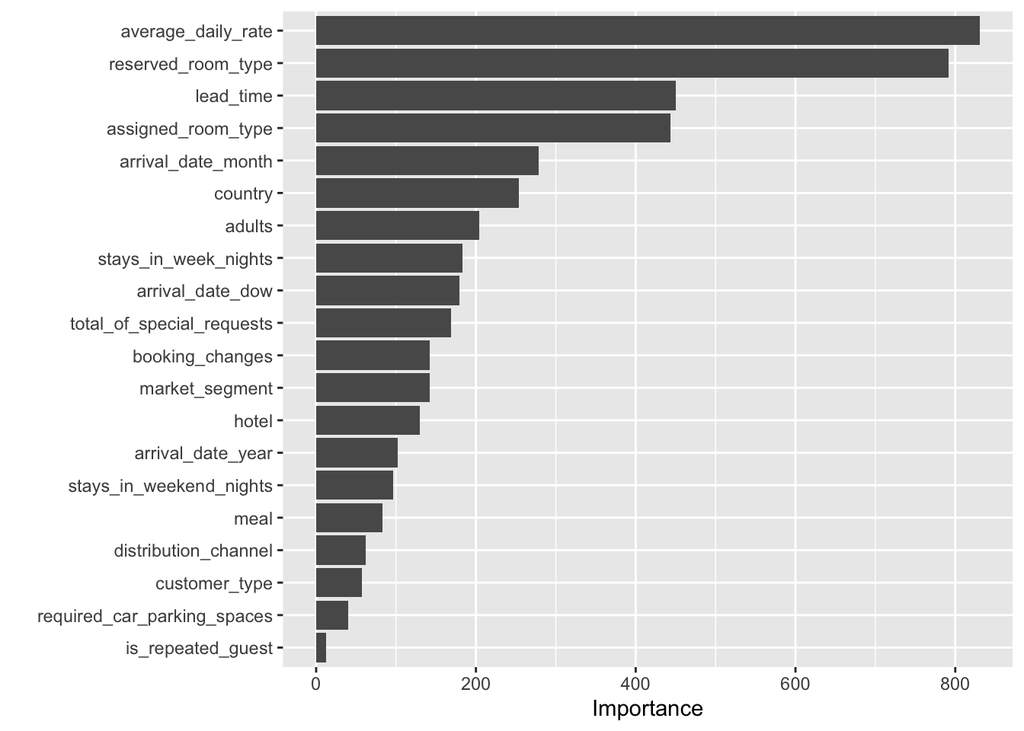

```r
last_rf_fit %>%
  extract_fit_parsnip() %>%
  vip(num_features = 20)
```

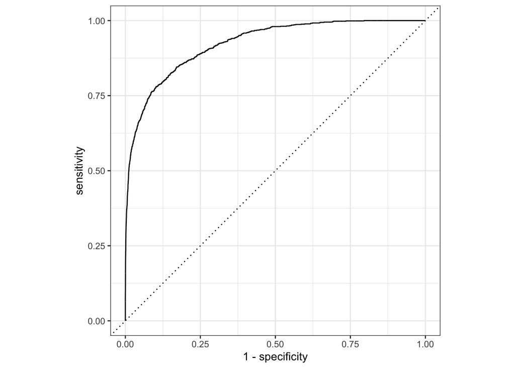

```r
last_rf_fit %>%
  collect_predictions() %>%
  roc_curve(children, .pred_children) %>%
  autoplot()
```

packages